# RP_Python_Decision_Tree_Titanic

```python
from IPython.display import Image
from IPython.core.display import HTML
import numpy as np
import pandas as pd
import pandas_profiling

from matplotlib import pyplot as plt
plt.rcParams.update({'font.size': 22})


import seaborn as sns
from sklearn import metrics, preprocessing, svm
from sklearn.naive_bayes import GaussianNB
from sklearn.svm import SVC

from sklearn.model_selection import train_test_split,cross_val_score, GridSearchCV
from sklearn.metrics import roc_curve, auc, recall_score, precision_score,accuracy_score,f1_score
from sklearn.metrics import confusion_matrix, average_precision_score,recall_score
from sklearn.ensemble import RandomForestClassifier
from sklearn.ensemble.gradient_boosting import GradientBoostingClassifier
from sklearn.linear_model import LogisticRegression, LogisticRegressionCV

import warnings
warnings.filterwarnings('ignore')
warnings.filterwarnings('ignore', category=DeprecationWarning)
%matplotlib inline
Image(url= "Capture.JPG")
```

[figure not shown]

```python
Image(url="Capture2.JPG")
```

[figure not shown]

Dictionary on DataSet of Titanic. survival: Survival (0 = no; 1 = yes) class: Passenger class (1 = first; 2 = second; 3 = third) name: Name sex: Sex age: Age sibsp: Number of siblings/spouses aboard parch: Number of parents/children aboard ticket: Ticket number fare: Passenger fare cabin: Cabin embarked: Port of embarkation (C = Cherbourg; Q = Queenstown; S = Southampton) boat: Lifeboat (if survived) body: Body number (if did not survive and body was recovered)

```python
Image(url="Capture1.JPG")
```

[figure not shown]

```python
#print multiple statements in same line
from IPython.core.interactiveshell import InteractiveShell
InteractiveShell.ast_node_interactivity ="all"
```

```python
titanicData = pd.read_excel('titanic.xls', index_col=None, na_values=['NA'])
```

```python
titanicData.sample(10)
titanicData.info()
```

|  | pclass | survived | name | sex | age | sibsp | parch | ticket | fare | cabin | embarked | boat | body | home.dest |
| --- | --- | --- | --- | --- | --- | --- | --- | --- | --- | --- | --- | --- | --- | --- |
| 1275 | 3 | 0 | Vander Planke, Mr. Leo Edmondus | male | 16.0 | 2 | 0 | 345764 | 18.0000 | NaN | S | NaN | NaN | NaN |
| 42 | 1 | 1 | Brown, Mrs. John Murray (Caroline Lane Lamson) | female | 59.0 | 2 | 0 | 11769 | 51.4792 | C101 | S | D | NaN | Belmont, MA |
| 1072 | 3 | 0 | O'Connell, Mr. Patrick D | male | NaN | 0 | 0 | 334912 | 7.7333 | NaN | Q | NaN | NaN | NaN |
| 510 | 2 | 0 | Mudd, Mr. Thomas Charles | male | 16.0 | 0 | 0 | S.O./P.P. 3 | 10.5000 | NaN | S | NaN | NaN | Halesworth, England |
| 688 | 3 | 0 | Braund, Mr. Lewis Richard | male | 29.0 | 1 | 0 | 3460 | 7.0458 | NaN | S | NaN | NaN | Bridgerule, Devon |
| 743 | 3 | 0 | Dahlberg, Miss. Gerda Ulrika | female | 22.0 | 0 | 0 | 7552 | 10.5167 | NaN | S | NaN | NaN | Norrlot, Sweden Chicago, IL |
| 566 | 2 | 0 | Stanton, Mr. Samuel Ward | male | 41.0 | 0 | 0 | 237734 | 15.0458 | NaN | C | NaN | NaN | New York, NY |
| 442 | 2 | 0 | Hickman, Mr. Leonard Mark | male | 24.0 | 2 | 0 | S.O.C. 14879 | 73.5000 | NaN | S | NaN | NaN | West Hampstead, London / Neepawa, MB |
| 437 | 2 | 1 | Herman, Miss. Alice | female | 24.0 | 1 | 2 | 220845 | 65.0000 | NaN | S | 9 | NaN | Somerset / Bernardsville, NJ |
| 127 | 1 | 1 | Futrelle, Mrs. Jacques Heath (Lily May Peel) | female | 35.0 | 1 | 0 | 113803 | 53.1000 | C123 | S | D | NaN | Scituate, MA |

```
<class 'pandas.core.frame.DataFrame'>
RangeIndex: 1309 entries, 0 to 1308
Data columns (total 14 columns):
pclass       1309 non-null int64
survived     1309 non-null int64
name         1309 non-null object
sex          1309 non-null object
age          1046 non-null float64
sibsp        1309 non-null int64
parch        1309 non-null int64
ticket       1309 non-null object
fare         1308 non-null float64
cabin        295 non-null object
embarked     1307 non-null object
boat         486 non-null object
body         121 non-null float64
home.dest    745 non-null object
dtypes: float64(3), int64(4), object(7)
memory usage: 143.2+ KB
```

# Exploratory Data Analysis

Overview

Dataset info

| Number of variables | 14 |
| --- | --- |
| Number of observations | 1309 |
| Total Missing (%) | 21.0% |
| Total size in memory | 143.2 KiB |
| Average record size in memory | 112.1 B |

Variables types

| Numeric | 6 |
| --- | --- |
| Categorical | 7 |
| Boolean | 1 |
| Date | 0 |
| Text (Unique) | 0 |
| Rejected | 0 |
| Unsupported | 0 |

Warnings

- `age` has 263 / 20.1% missing values Missing

- `boat` has 823 / 62.9% missing values Missing

- `body` has 1188 / 90.8% missing values Missing

- `cabin` has 1014 / 77.5% missing values Missing

- `cabin` has a high cardinality: 187 distinct values Warning

- `fare` has 17 / 1.3% zeros Zeros

- `home.dest` has 564 / 43.1% missing values Missing

- `home.dest` has a high cardinality: 370 distinct values Warning

- `name` has a high cardinality: 1307 distinct values Warning

- `parch` has 1002 / 76.5% zeros Zeros

- `sibsp` has 891 / 68.1% zeros Zeros

- `ticket` has a high cardinality: 939 distinct values Warning

Variables

age  
Numeric

| Distinct count | 99 |
| --- | --- |
| Unique (%) | 7.6% |
| Missing (%) | 20.1% |
| Missing (n) | 263 |
| Infinite (%) | 0.0% |
| Infinite (n) | 0 |

| Mean | 29.881 |
| --- | --- |
| Minimum | 0.1667 |
| Maximum | 80 |
| Zeros (%) | 0.0% |

Toggle details

**Statistics**

Quantile statistics

| Minimum | 0.1667 |
| --- | --- |
| 5-th percentile | 5 |
| Q1 | 21 |
| Median | 28 |
| Q3 | 39 |
| 95-th percentile | 57 |
| Maximum | 80 |
| Range | 79.833 |
| Interquartile range | 18 |

Descriptive statistics

| Standard deviation | 14.413 |
| --- | --- |
| Coef of variation | 0.48236 |
| Kurtosis | 0.14695 |
| Mean | 29.881 |
| MAD | 11.262 |
| Skewness | 0.40767 |
| Sum | 31256 |
| Variance | 207.75 |
| Memory size | 10.3 KiB |

**Histogram**

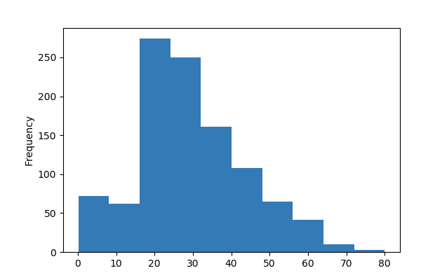

**Common Values**

| Value | Count | Frequency (%) |  |
| --- | --- | --- | --- |
| 24.0 | 47 | 3.6% |  |
| 22.0 | 43 | 3.3% |  |
| 21.0 | 41 | 3.1% |  |
| 30.0 | 40 | 3.1% |  |
| 18.0 | 39 | 3.0% |  |
| 25.0 | 34 | 2.6% |  |
| 28.0 | 32 | 2.4% |  |
| 36.0 | 31 | 2.4% |  |
| 27.0 | 30 | 2.3% |  |
| 29.0 | 30 | 2.3% |  |
| Other values (88) | 679 | 51.9% |  |
| (Missing) | 263 | 20.1% |  |

**Extreme Values**

Minimum 5 values

| Value | Count | Frequency (%) |  |
| --- | --- | --- | --- |
| 0.1667 | 1 | 0.1% |  |
| 0.3333 | 1 | 0.1% |  |
| 0.4167 | 1 | 0.1% |  |
| 0.6667 | 1 | 0.1% |  |
| 0.75 | 3 | 0.2% |  |

Maximum 5 values

| Value | Count | Frequency (%) |  |
| --- | --- | --- | --- |
| 70.5 | 1 | 0.1% |  |
| 71.0 | 2 | 0.2% |  |
| 74.0 | 1 | 0.1% |  |
| 76.0 | 1 | 0.1% |  |
| 80.0 | 1 | 0.1% |  |

boat  
Categorical

| Distinct count | 29 |
| --- | --- |
| Unique (%) | 2.2% |
| Missing (%) | 62.9% |
| Missing (n) | 823 |

| 13 | 39 |
| --- | --- |
| C | 38 |
| 15 | 37 |
| Other values (25) | 372 |
| (Missing) | 823 |

Toggle details

| Value | Count | Frequency (%) |  |
| --- | --- | --- | --- |
| 13 | 39 | 3.0% |  |
| C | 38 | 2.9% |  |
| 15 | 37 | 2.8% |  |
| 14 | 33 | 2.5% |  |
| 4 | 31 | 2.4% |  |
| 10 | 29 | 2.2% |  |
| 5 | 27 | 2.1% |  |
| 3 | 26 | 2.0% |  |
| 9 | 25 | 1.9% |  |
| 11 | 25 | 1.9% |  |
| Other values (18) | 176 | 13.4% |  |
| (Missing) | 823 | 62.9% |  |

body  
Numeric

| Distinct count | 122 |
| --- | --- |
| Unique (%) | 9.3% |
| Missing (%) | 90.8% |
| Missing (n) | 1188 |
| Infinite (%) | 0.0% |
| Infinite (n) | 0 |

| Mean | 160.81 |
| --- | --- |
| Minimum | 1 |
| Maximum | 328 |
| Zeros (%) | 0.0% |

Toggle details

**Statistics**

Quantile statistics

| Minimum | 1 |
| --- | --- |
| 5-th percentile | 16 |
| Q1 | 72 |
| Median | 155 |
| Q3 | 256 |
| 95-th percentile | 307 |
| Maximum | 328 |
| Range | 327 |
| Interquartile range | 184 |

Descriptive statistics

| Standard deviation | 97.697 |
| --- | --- |
| Coef of variation | 0.60753 |
| Kurtosis | -1.2541 |
| Mean | 160.81 |
| MAD | 84.169 |
| Skewness | 0.091739 |
| Sum | 19458 |
| Variance | 9544.7 |
| Memory size | 10.3 KiB |

**Histogram**

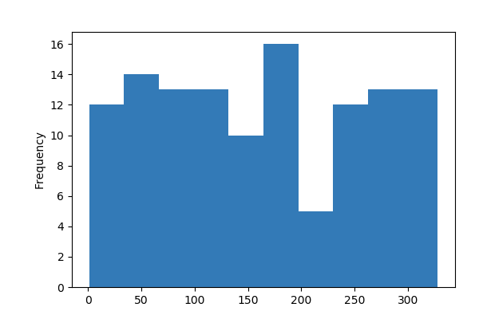

**Common Values**

| Value | Count | Frequency (%) |  |
| --- | --- | --- | --- |
| 142.0 | 1 | 0.1% |  |
| 68.0 | 1 | 0.1% |  |
| 47.0 | 1 | 0.1% |  |
| 98.0 | 1 | 0.1% |  |
| 188.0 | 1 | 0.1% |  |
| 120.0 | 1 | 0.1% |  |
| 156.0 | 1 | 0.1% |  |
| 37.0 | 1 | 0.1% |  |
| 58.0 | 1 | 0.1% |  |
| 70.0 | 1 | 0.1% |  |
| Other values (111) | 111 | 8.5% |  |
| (Missing) | 1188 | 90.8% |  |

**Extreme Values**

Minimum 5 values

| Value | Count | Frequency (%) |  |
| --- | --- | --- | --- |
| 1.0 | 1 | 0.1% |  |
| 4.0 | 1 | 0.1% |  |
| 7.0 | 1 | 0.1% |  |
| 9.0 | 1 | 0.1% |  |
| 14.0 | 1 | 0.1% |  |

Maximum 5 values

| Value | Count | Frequency (%) |  |
| --- | --- | --- | --- |
| 312.0 | 1 | 0.1% |  |
| 314.0 | 1 | 0.1% |  |
| 322.0 | 1 | 0.1% |  |
| 327.0 | 1 | 0.1% |  |
| 328.0 | 1 | 0.1% |  |

cabin  
Categorical

| Distinct count | 187 |
| --- | --- |
| Unique (%) | 14.3% |
| Missing (%) | 77.5% |
| Missing (n) | 1014 |

| C23 C25 C27 | 6 |
| --- | --- |
| B57 B59 B63 B66 | 5 |
| G6 | 5 |
| Other values (183) | 279 |
| (Missing) | 1014 |

Toggle details

| Value | Count | Frequency (%) |  |
| --- | --- | --- | --- |
| C23 C25 C27 | 6 | 0.5% |  |
| B57 B59 B63 B66 | 5 | 0.4% |  |
| G6 | 5 | 0.4% |  |
| F33 | 4 | 0.3% |  |
| C22 C26 | 4 | 0.3% |  |
| F2 | 4 | 0.3% |  |
| B96 B98 | 4 | 0.3% |  |
| D | 4 | 0.3% |  |
| C78 | 4 | 0.3% |  |
| F4 | 4 | 0.3% |  |
| Other values (176) | 251 | 19.2% |  |
| (Missing) | 1014 | 77.5% |  |

embarked  
Categorical

| Distinct count | 4 |
| --- | --- |
| Unique (%) | 0.3% |
| Missing (%) | 0.2% |
| Missing (n) | 2 |

| S | 914 |
| --- | --- |
| C | 270 |
| Q | 123 |
| (Missing) | 2 |

Toggle details

| Value | Count | Frequency (%) |  |
| --- | --- | --- | --- |
| S | 914 | 69.8% |  |
| C | 270 | 20.6% |  |
| Q | 123 | 9.4% |  |
| (Missing) | 2 | 0.2% |  |

fare  
Numeric

| Distinct count | 282 |
| --- | --- |
| Unique (%) | 21.5% |
| Missing (%) | 0.1% |
| Missing (n) | 1 |
| Infinite (%) | 0.0% |
| Infinite (n) | 0 |

| Mean | 33.295 |
| --- | --- |
| Minimum | 0 |
| Maximum | 512.33 |
| Zeros (%) | 1.3% |

Toggle details

**Statistics**

Quantile statistics

| Minimum | 0 |
| --- | --- |
| 5-th percentile | 7.225 |
| Q1 | 7.8958 |
| Median | 14.454 |
| Q3 | 31.275 |
| 95-th percentile | 133.65 |
| Maximum | 512.33 |
| Range | 512.33 |
| Interquartile range | 23.379 |

Descriptive statistics

| Standard deviation | 51.759 |
| --- | --- |
| Coef of variation | 1.5545 |
| Kurtosis | 27.028 |
| Mean | 33.295 |
| MAD | 29.799 |
| Skewness | 4.3677 |
| Sum | 43550 |
| Variance | 2679 |
| Memory size | 10.3 KiB |

**Histogram**

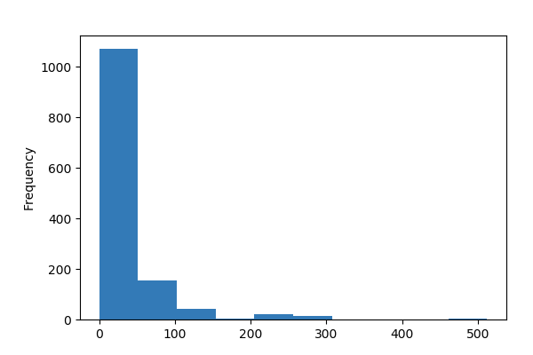

**Common Values**

| Value | Count | Frequency (%) |  |
| --- | --- | --- | --- |
| 8.05 | 60 | 4.6% |  |
| 13.0 | 59 | 4.5% |  |
| 7.75 | 55 | 4.2% |  |
| 26.0 | 50 | 3.8% |  |
| 7.8958 | 49 | 3.7% |  |
| 10.5 | 35 | 2.7% |  |
| 7.775 | 26 | 2.0% |  |
| 7.2292 | 24 | 1.8% |  |
| 7.925 | 23 | 1.8% |  |
| 26.55 | 22 | 1.7% |  |
| Other values (271) | 905 | 69.1% |  |

**Extreme Values**

Minimum 5 values

| Value | Count | Frequency (%) |  |
| --- | --- | --- | --- |
| 0.0 | 17 | 1.3% |  |
| 3.1708 | 1 | 0.1% |  |
| 4.0125 | 1 | 0.1% |  |
| 5.0 | 1 | 0.1% |  |
| 6.2375 | 1 | 0.1% |  |

Maximum 5 values

| Value | Count | Frequency (%) |  |
| --- | --- | --- | --- |
| 227.525 | 5 | 0.4% |  |
| 247.5208 | 3 | 0.2% |  |
| 262.375 | 7 | 0.5% |  |
| 263.0 | 6 | 0.5% |  |
| 512.3292 | 4 | 0.3% |  |

home.dest  
Categorical

| Distinct count | 370 |
| --- | --- |
| Unique (%) | 28.3% |
| Missing (%) | 43.1% |
| Missing (n) | 564 |

| New York, NY | 64 |
| --- | --- |
| London | 14 |
| Montreal, PQ | 10 |
| Other values (366) | 657 |
| (Missing) | 564 |

Toggle details

| Value | Count | Frequency (%) |  |
| --- | --- | --- | --- |
| New York, NY | 64 | 4.9% |  |
| London | 14 | 1.1% |  |
| Montreal, PQ | 10 | 0.8% |  |
| Paris, France | 9 | 0.7% |  |
| Cornwall / Akron, OH | 9 | 0.7% |  |
| Winnipeg, MB | 8 | 0.6% |  |
| Philadelphia, PA | 8 | 0.6% |  |
| Wiltshire, England Niagara Falls, NY | 8 | 0.6% |  |
| Brooklyn, NY | 7 | 0.5% |  |
| Sweden Winnipeg, MN | 7 | 0.5% |  |
| Other values (359) | 601 | 45.9% |  |
| (Missing) | 564 | 43.1% |  |

name  
Categorical

| Distinct count | 1307 |
| --- | --- |
| Unique (%) | 99.8% |
| Missing (%) | 0.0% |
| Missing (n) | 0 |

| Kelly, Mr. James | 2 |
| --- | --- |
| Connolly, Miss. Kate | 2 |
| Campbell, Mr. William | 1 |
| Other values (1304) | 1304 |

Toggle details

| Value | Count | Frequency (%) |  |
| --- | --- | --- | --- |
| Kelly, Mr. James | 2 | 0.2% |  |
| Connolly, Miss. Kate | 2 | 0.2% |  |
| Campbell, Mr. William | 1 | 0.1% |  |
| Williams, Mr. Richard Norris II | 1 | 0.1% |  |
| Van Impe, Mr. Jean Baptiste | 1 | 0.1% |  |
| Parr, Mr. William Henry Marsh | 1 | 0.1% |  |
| Whabee, Mrs. George Joseph (Shawneene Abi-Saab) | 1 | 0.1% |  |
| Olsen, Mr. Henry Margido | 1 | 0.1% |  |
| Hyman, Mr. Abraham | 1 | 0.1% |  |
| Nye, Mrs. (Elizabeth Ramell) | 1 | 0.1% |  |
| Other values (1297) | 1297 | 99.1% |  |

parch  
Numeric

| Distinct count | 8 |
| --- | --- |
| Unique (%) | 0.6% |
| Missing (%) | 0.0% |
| Missing (n) | 0 |
| Infinite (%) | 0.0% |
| Infinite (n) | 0 |

| Mean | 0.38503 |
| --- | --- |
| Minimum | 0 |
| Maximum | 9 |
| Zeros (%) | 76.5% |

Toggle details

**Statistics**

Quantile statistics

| Minimum | 0 |
| --- | --- |
| 5-th percentile | 0 |
| Q1 | 0 |
| Median | 0 |
| Q3 | 0 |
| 95-th percentile | 2 |
| Maximum | 9 |
| Range | 9 |
| Interquartile range | 0 |

Descriptive statistics

| Standard deviation | 0.86556 |
| --- | --- |
| Coef of variation | 2.2481 |
| Kurtosis | 21.541 |
| Mean | 0.38503 |
| MAD | 0.58945 |
| Skewness | 3.6691 |
| Sum | 504 |
| Variance | 0.74919 |
| Memory size | 10.3 KiB |

**Histogram**

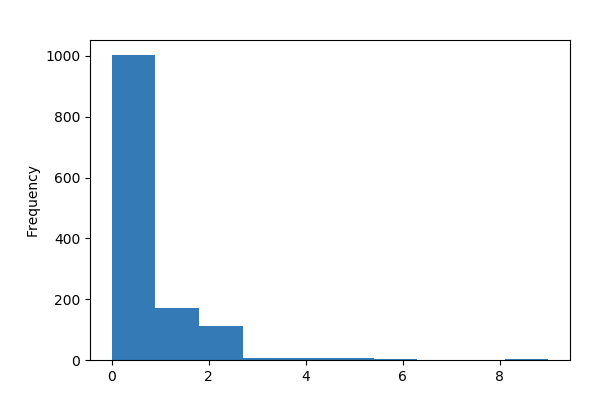

**Common Values**

| Value | Count | Frequency (%) |  |
| --- | --- | --- | --- |
| 0 | 1002 | 76.5% |  |
| 1 | 170 | 13.0% |  |
| 2 | 113 | 8.6% |  |
| 3 | 8 | 0.6% |  |
| 5 | 6 | 0.5% |  |
| 4 | 6 | 0.5% |  |
| 9 | 2 | 0.2% |  |
| 6 | 2 | 0.2% |  |

**Extreme Values**

Minimum 5 values

| Value | Count | Frequency (%) |  |
| --- | --- | --- | --- |
| 0 | 1002 | 76.5% |  |
| 1 | 170 | 13.0% |  |
| 2 | 113 | 8.6% |  |
| 3 | 8 | 0.6% |  |
| 4 | 6 | 0.5% |  |

Maximum 5 values

| Value | Count | Frequency (%) |  |
| --- | --- | --- | --- |
| 3 | 8 | 0.6% |  |
| 4 | 6 | 0.5% |  |
| 5 | 6 | 0.5% |  |
| 6 | 2 | 0.2% |  |
| 9 | 2 | 0.2% |  |

pclass  
Numeric

| Distinct count | 3 |
| --- | --- |
| Unique (%) | 0.2% |
| Missing (%) | 0.0% |
| Missing (n) | 0 |
| Infinite (%) | 0.0% |
| Infinite (n) | 0 |

| Mean | 2.2949 |
| --- | --- |
| Minimum | 1 |
| Maximum | 3 |
| Zeros (%) | 0.0% |

Toggle details

**Statistics**

Quantile statistics

| Minimum | 1 |
| --- | --- |
| 5-th percentile | 1 |
| Q1 | 2 |
| Median | 3 |
| Q3 | 3 |
| 95-th percentile | 3 |
| Maximum | 3 |
| Range | 2 |
| Interquartile range | 1 |

Descriptive statistics

| Standard deviation | 0.83784 |
| --- | --- |
| Coef of variation | 0.36509 |
| Kurtosis | -1.3151 |
| Mean | 2.2949 |
| MAD | 0.76383 |
| Skewness | -0.59865 |
| Sum | 3004 |
| Variance | 0.70197 |
| Memory size | 10.3 KiB |

**Histogram**

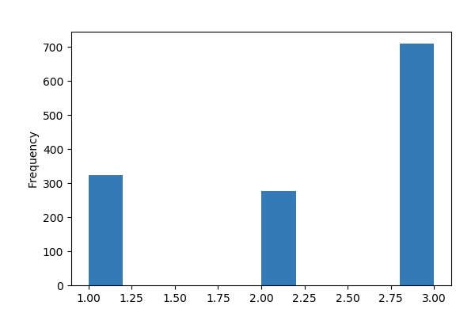

**Common Values**

| Value | Count | Frequency (%) |  |
| --- | --- | --- | --- |
| 3 | 709 | 54.2% |  |
| 1 | 323 | 24.7% |  |
| 2 | 277 | 21.2% |  |

**Extreme Values**

Minimum 5 values

| Value | Count | Frequency (%) |  |
| --- | --- | --- | --- |
| 1 | 323 | 24.7% |  |
| 2 | 277 | 21.2% |  |
| 3 | 709 | 54.2% |  |

Maximum 5 values

| Value | Count | Frequency (%) |  |
| --- | --- | --- | --- |
| 1 | 323 | 24.7% |  |
| 2 | 277 | 21.2% |  |
| 3 | 709 | 54.2% |  |

sex  
Categorical

| Distinct count | 2 |
| --- | --- |
| Unique (%) | 0.2% |
| Missing (%) | 0.0% |
| Missing (n) | 0 |

| male | 843 |
| --- | --- |
| female | 466 |

Toggle details

| Value | Count | Frequency (%) |  |
| --- | --- | --- | --- |
| male | 843 | 64.4% |  |
| female | 466 | 35.6% |  |

sibsp  
Numeric

| Distinct count | 7 |
| --- | --- |
| Unique (%) | 0.5% |
| Missing (%) | 0.0% |
| Missing (n) | 0 |
| Infinite (%) | 0.0% |
| Infinite (n) | 0 |

| Mean | 0.49885 |
| --- | --- |
| Minimum | 0 |
| Maximum | 8 |
| Zeros (%) | 68.1% |

Toggle details

**Statistics**

Quantile statistics

| Minimum | 0 |
| --- | --- |
| 5-th percentile | 0 |
| Q1 | 0 |
| Median | 0 |
| Q3 | 1 |
| 95-th percentile | 2 |
| Maximum | 8 |
| Range | 8 |
| Interquartile range | 1 |

Descriptive statistics

| Standard deviation | 1.0417 |
| --- | --- |
| Coef of variation | 2.0881 |
| Kurtosis | 20.043 |
| Mean | 0.49885 |
| MAD | 0.67911 |
| Skewness | 3.8442 |
| Sum | 653 |
| Variance | 1.0851 |
| Memory size | 10.3 KiB |

**Histogram**

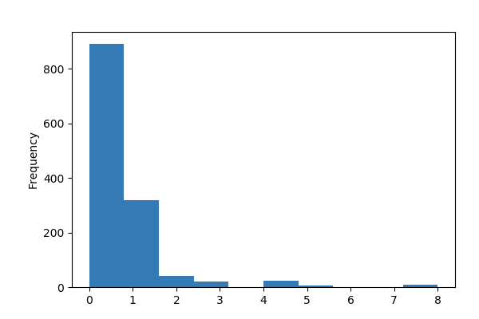

**Common Values**

| Value | Count | Frequency (%) |  |
| --- | --- | --- | --- |
| 0 | 891 | 68.1% |  |
| 1 | 319 | 24.4% |  |
| 2 | 42 | 3.2% |  |
| 4 | 22 | 1.7% |  |
| 3 | 20 | 1.5% |  |
| 8 | 9 | 0.7% |  |
| 5 | 6 | 0.5% |  |

**Extreme Values**

Minimum 5 values

| Value | Count | Frequency (%) |  |
| --- | --- | --- | --- |
| 0 | 891 | 68.1% |  |
| 1 | 319 | 24.4% |  |
| 2 | 42 | 3.2% |  |
| 3 | 20 | 1.5% |  |
| 4 | 22 | 1.7% |  |

Maximum 5 values

| Value | Count | Frequency (%) |  |
| --- | --- | --- | --- |
| 2 | 42 | 3.2% |  |
| 3 | 20 | 1.5% |  |
| 4 | 22 | 1.7% |  |
| 5 | 6 | 0.5% |  |
| 8 | 9 | 0.7% |  |

survived  
Boolean

| Distinct count | 2 |
| --- | --- |
| Unique (%) | 0.2% |
| Missing (%) | 0.0% |
| Missing (n) | 0 |

| Mean | 0.38197 |
| --- | --- |

| 0 | 809 |
| --- | --- |
| 1 | 500 |

Toggle details

| Value | Count | Frequency (%) |  |
| --- | --- | --- | --- |
| 0 | 809 | 61.8% |  |
| 1 | 500 | 38.2% |  |

ticket  
Categorical

| Distinct count | 939 |
| --- | --- |
| Unique (%) | 71.7% |
| Missing (%) | 0.0% |
| Missing (n) | 0 |

| CA. 2343 | 11 |
| --- | --- |
| 1601 | 8 |
| CA 2144 | 8 |
| Other values (936) | 1282 |

Toggle details

| Value | Count | Frequency (%) |  |
| --- | --- | --- | --- |
| CA. 2343 | 11 | 0.8% |  |
| 1601 | 8 | 0.6% |  |
| CA 2144 | 8 | 0.6% |  |
| 347082 | 7 | 0.5% |  |
| S.O.C. 14879 | 7 | 0.5% |  |
| 347077 | 7 | 0.5% |  |
| PC 17608 | 7 | 0.5% |  |
| 3101295 | 7 | 0.5% |  |
| 347088 | 6 | 0.5% |  |
| 19950 | 6 | 0.5% |  |
| Other values (929) | 1235 | 94.3% |  |

Correlations

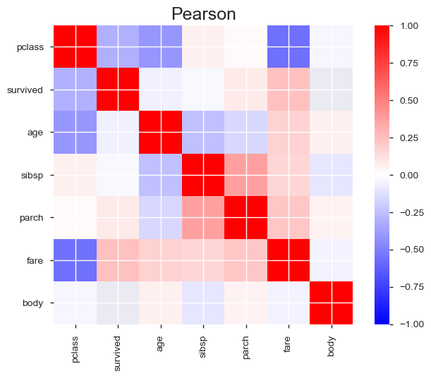

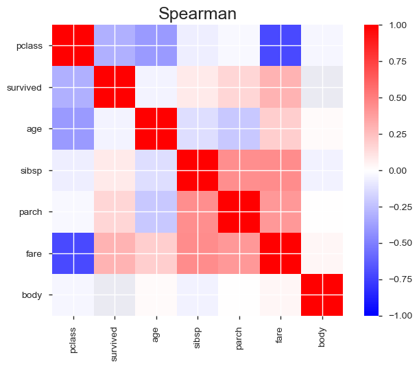

Sample

|  | pclass | survived | name | sex | age | sibsp | parch | ticket | fare | cabin | embarked | boat | body | home.dest |
| --- | --- | --- | --- | --- | --- | --- | --- | --- | --- | --- | --- | --- | --- | --- |
| 0 | 1 | 1 | Allen, Miss. Elisabeth Walton | female | 29.0000 | 0 | 0 | 24160 | 211.3375 | B5 | S | 2 | NaN | St Louis, MO |
| 1 | 1 | 1 | Allison, Master. Hudson Trevor | male | 0.9167 | 1 | 2 | 113781 | 151.5500 | C22 C26 | S | 11 | NaN | Montreal, PQ / Chesterville, ON |
| 2 | 1 | 0 | Allison, Miss. Helen Loraine | female | 2.0000 | 1 | 2 | 113781 | 151.5500 | C22 C26 | S | NaN | NaN | Montreal, PQ / Chesterville, ON |
| 3 | 1 | 0 | Allison, Mr. Hudson Joshua Creighton | male | 30.0000 | 1 | 2 | 113781 | 151.5500 | C22 C26 | S | NaN | 135.0 | Montreal, PQ / Chesterville, ON |
| 4 | 1 | 0 | Allison, Mrs. Hudson J C (Bessie Waldo Daniels) | female | 25.0000 | 1 | 2 | 113781 | 151.5500 | C22 C26 | S | NaN | NaN | Montreal, PQ / Chesterville, ON |

```python
pandas_profiling.ProfileReport(titanicData)
```

```python
titanicData.describe()
```

|  | pclass | survived | age | sibsp | parch | fare | body |
| --- | --- | --- | --- | --- | --- | --- | --- |
| count | 1309.000000 | 1309.000000 | 1046.000000 | 1309.000000 | 1309.000000 | 1308.000000 | 121.000000 |
| mean | 2.294882 | 0.381971 | 29.881135 | 0.498854 | 0.385027 | 33.295479 | 160.809917 |
| std | 0.837836 | 0.486055 | 14.413500 | 1.041658 | 0.865560 | 51.758668 | 97.696922 |
| min | 1.000000 | 0.000000 | 0.166700 | 0.000000 | 0.000000 | 0.000000 | 1.000000 |
| 25% | 2.000000 | 0.000000 | 21.000000 | 0.000000 | 0.000000 | 7.895800 | 72.000000 |
| 50% | 3.000000 | 0.000000 | 28.000000 | 0.000000 | 0.000000 | 14.454200 | 155.000000 |
| 75% | 3.000000 | 1.000000 | 39.000000 | 1.000000 | 0.000000 | 31.275000 | 256.000000 |
| max | 3.000000 | 1.000000 | 80.000000 | 8.000000 | 9.000000 | 512.329200 | 328.000000 |

# Data Visualization

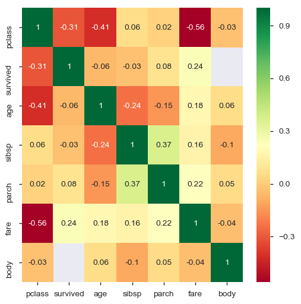

```python
# compute the pair wise correlation for all columns
correlation_matrix = titanicData.corr().round(2)
plt.subplots(figsize=(6,6))
# use the heatmap function from seaborn to plot the correlation matrix
# annot = True to print the values inside the square
sns.heatmap(data=correlation_matrix, cmap='RdYlGn',annot=True)
plt.show();
```

```python
#List of columns of titanicData
titanicData.columns
titanicData.shape
```

```
Index(['pclass', 'survived', 'name', 'sex', 'age', 'sibsp', 'parch', 'ticket',
       'fare', 'cabin', 'embarked', 'boat', 'body', 'home.dest'],
      dtype='object')
```

```
(1309, 14)
```

## % of the Survived on overall population

```python
#let’s examine the overall chance of survival for a Titanic passenger.
titanicData['survived'].mean()
```

```
0.3819709702062643
```

The calculation shows that only 38% of the passengers survived. Not the best odds. The reason for this massive loss of life is that the Titanic was only carrying 20 lifeboats, which was not nearly enough for the 1,309 passengers and 885 crew members aboard. It seems unlikely that all of the passengers would have had equal chances at survival, so we will continue breaking down the data to examine the social dynamics that determined who got a place on a lifeboat and who did not.

```python
#To get a view into the composition of each class, we can group data by class, and view the averages for each column:
titanicData.groupby('pclass').mean()
```

| pclass | survived | age | sibsp | parch | fare | body |
| --- | --- | --- | --- | --- | --- | --- |
| 1 | 0.619195 | 39.159918 | 0.436533 | 0.365325 | 87.508992 | 162.828571 |
| 2 | 0.429603 | 29.506705 | 0.393502 | 0.368231 | 21.179196 | 167.387097 |
| 3 | 0.255289 | 24.816367 | 0.568406 | 0.400564 | 13.302889 | 155.818182 |

For instance, passengers in first class had a 62% chance of survival, compared to a 25.5% chance for those in 3rd class. Additionally, the lower classes generally consisted of younger people, and the ticket prices for first class were predictably much higher than those for second and third class.

```python
#Replacing pclass 1,2,3 with 1 = first; 2 = second; 3 = third
titanicData['pclass'] = titanicData['pclass'].replace(1,'First')
titanicData['pclass'] = titanicData['pclass'].replace(2,'Second')
titanicData['pclass'] = titanicData['pclass'].replace(3,'Third')
```

```
Counts of Labels
```

```
pclass
First     323
Second    277
Third     709
dtype: int64
```

```
 [Text(-0.7698434129518064, 0.7857105825523254, 'First Class'),
 [Text(-0.4199145888828035, 0.4285694086649047, '24.7%'),
```

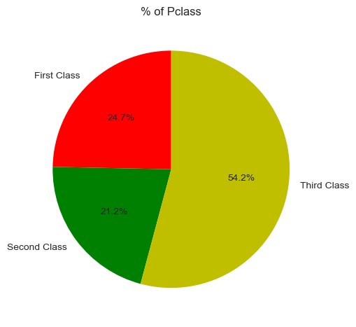

```python
print('Counts of Labels')
class_group = titanicData.groupby("pclass").size()
class_group
plt.pie(class_group,
        labels=['First Class', 'Second Class','Third Class'],
        colors= ['r', 'g','y'],
        startangle=90,
        autopct='%.1f%%')
plt.title('% of Pclass')
plt.show()
```

```python
#Replacing embarked S,C, Q (C = Cherbourg; Q = Queenstown; S = Southampton)
titanicData['embarked'] = titanicData['embarked'].replace('C','Cherbourg')
titanicData['embarked'] = titanicData['embarked'].replace('S','Southampton')
titanicData['embarked'] = titanicData['embarked'].replace('Q','Queenstown')
```

```
 [Text(-0.6648203139754177, 0.8763640511372127, 'Cherbourg'),
 [Text(-0.3626292621684097, 0.4780167551657523, '20.7%'),
```

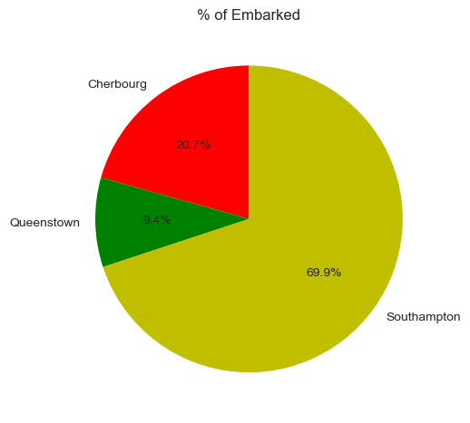

```python
plt.pie(titanicData.groupby("embarked").size(),
        labels=['Cherbourg', 'Queenstown','Southampton'],
        colors= ['r', 'g','y'],
        startangle=90,
        autopct='%.1f%%')
plt.title('% of Embarked')
plt.show()
```

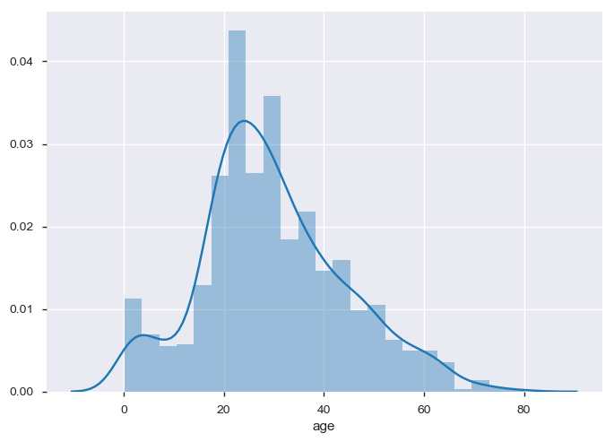

```python
sns.distplot(titanicData.age.dropna())
```

```python
#Now lets see by grouping function for both class and sex:
class_sex_grouping = titanicData.groupby(['pclass','sex']).mean()
class_sex_grouping
```

| pclass | sex | survived | age | sibsp | parch | fare | body |
| --- | --- | --- | --- | --- | --- | --- | --- |
| First | female | 0.965278 | 37.037594 | 0.555556 | 0.472222 | 109.412385 | NaN |
|  | male | 0.340782 | 41.029250 | 0.340782 | 0.279330 | 69.888385 | 162.828571 |
| Second | female | 0.886792 | 27.499191 | 0.500000 | 0.650943 | 23.234827 | 52.000000 |
|  | male | 0.146199 | 30.815401 | 0.327485 | 0.192982 | 19.904946 | 171.233333 |
| Third | female | 0.490741 | 22.185307 | 0.791667 | 0.731481 | 15.324250 | 183.000000 |
|  | male | 0.152130 | 25.962273 | 0.470588 | 0.255578 | 12.415462 | 151.854167 |

```python
pd.crosstab(titanicData['sibsp'],titanicData['survived']).style.background_gradient('summer_r')
```

| survived sibsp | 0 | 1 |
| --- | --- | --- |
| 0 | 582 | 309 |
| 1 | 156 | 163 |
| 2 | 23 | 19 |
| 3 | 14 | 6 |
| 4 | 19 | 3 |
| 5 | 6 | 0 |
| 8 | 9 | 0 |

sibsip feature indicates that whether a person is alone or with his family. Siblings=brother,sister, etc and Spouse= husband,wife

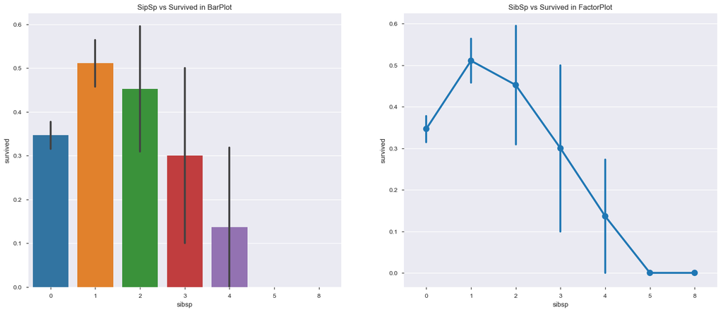

```python
f,ax=plt.subplots(1,2,figsize=(20,8))
sns.barplot('sibsp','survived', data=titanicData,ax=ax[0])
ax[0].set_title('SipSp vs Survived in BarPlot')
sns.factorplot('sibsp','survived', data=titanicData,ax=ax[1])
ax[1].set_title('SibSp vs Survived in FactorPlot')
plt.close(2)
plt.show()
```

```python
#Now lets see by grouping function for both class, survived and sex:
titanicData.pivot_table('survived', index='sex', columns='pclass')
```

| pclass sex | First | Second | Third |
| --- | --- | --- | --- |
| female | 0.965278 | 0.886792 | 0.490741 |
| male | 0.340782 | 0.146199 | 0.152130 |

```python
# Based on the age group using survived, age, pclass and sex
age = pd.cut(titanicData['age'], [0,10,20,30,40,50,60,70,80])
titanicData.pivot_table('survived', ['sex', age], 'pclass')
```

| sex | pclass age | First | Second | Third |
| --- | --- | --- | --- | --- |
| female | (0, 10] | 0.000000 | 1.000000 | 0.482759 |
|  | (10, 20] | 1.000000 | 0.937500 | 0.540541 |
|  | (20, 30] | 0.969697 | 0.850000 | 0.471698 |
|  | (30, 40] | 0.970588 | 0.950000 | 0.428571 |
|  | (40, 50] | 0.956522 | 0.916667 | 0.272727 |
|  | (50, 60] | 1.000000 | 0.500000 | NaN |
|  | (60, 70] | 0.800000 | NaN | 1.000000 |
|  | (70, 80] | 1.000000 | NaN | NaN |
| male | (0, 10] | 1.000000 | 1.000000 | 0.354839 |
|  | (10, 20] | 0.428571 | 0.117647 | 0.128571 |
|  | (20, 30] | 0.400000 | 0.081967 | 0.180556 |
|  | (30, 40] | 0.437500 | 0.085714 | 0.161765 |
|  | (40, 50] | 0.309524 | 0.055556 | 0.076923 |
|  | (50, 60] | 0.318182 | 0.000000 | 0.000000 |
|  | (60, 70] | 0.000000 | 0.166667 | 0.000000 |
|  | (70, 80] | 0.333333 | NaN | 0.000000 |

```python
# Based on the fare group using survived, fare, pclass, sex and age
fare = pd.qcut(titanicData['fare'],6)
titanicData.pivot_table('survived', ['sex', age], [fare, 'pclass'])
```

| sex | fare pclass age | (-0.001, 7.775] First | (-0.001, 7.775] Third | (7.775, 8.662] Third | (8.662, 14.454] Second | (8.662, 14.454] Third | (14.454, 26.0] First | (14.454, 26.0] Second | (14.454, 26.0] Third | (26.0, 53.1] First | (26.0, 53.1] Second | (26.0, 53.1] Third | (53.1, 512.329] First | (53.1, 512.329] Second | (53.1, 512.329] Third |
| --- | --- | --- | --- | --- | --- | --- | --- | --- | --- | --- | --- | --- | --- | --- | --- |
| female | (0, 10] | NaN | NaN | NaN | NaN | 0.571429 | NaN | 1.000000 | 0.642857 | NaN | 1.000000 | 0.125000 | 0.000000 | NaN | NaN |
|  | (10, 20] | NaN | 0.666667 | 0.600000 | 0.800000 | 0.571429 | NaN | 1.000000 | 0.333333 | 1.000000 | 1.000000 | 0.000000 | 1.000000 | NaN | NaN |
|  | (20, 30] | NaN | 0.642857 | 0.333333 | 0.875000 | 0.461538 | NaN | 0.750000 | 0.555556 | 1.000000 | 1.000000 | 0.000000 | 0.964286 | 1.0 | NaN |
|  | (30, 40] | NaN | 0.200000 | 0.000000 | 0.875000 | 0.250000 | NaN | 1.000000 | 0.750000 | 0.800000 | 1.000000 | 0.333333 | 1.000000 | NaN | NaN |
|  | (40, 50] | NaN | 0.666667 | NaN | 1.000000 | 0.500000 | 1.0 | 0.750000 | 0.000000 | 0.800000 | 1.000000 | 0.000000 | 1.000000 | 1.0 | NaN |
|  | (50, 60] | NaN | NaN | NaN | 0.000000 | NaN | 1.0 | 0.666667 | NaN | 1.000000 | NaN | NaN | 1.000000 | NaN | NaN |
|  | (60, 70] | NaN | NaN | NaN | NaN | 1.000000 | NaN | NaN | NaN | 1.000000 | NaN | NaN | 0.750000 | NaN | NaN |
|  | (70, 80] | NaN | NaN | NaN | NaN | NaN | NaN | NaN | NaN | NaN | NaN | NaN | 1.000000 | NaN | NaN |
| male | (0, 10] | NaN | 1.000000 | 1.000000 | NaN | 0.600000 | NaN | 1.000000 | 0.625000 | NaN | 1.000000 | 0.062500 | 1.000000 | NaN | NaN |
|  | (10, 20] | NaN | 0.055556 | 0.185185 | 0.181818 | 0.222222 | NaN | 0.000000 | 0.125000 | 0.000000 | 0.000000 | 0.000000 | 0.600000 | 0.0 | 0.0 |
|  | (20, 30] | NaN | 0.235294 | 0.125000 | 0.100000 | 0.214286 | 0.0 | 0.000000 | 0.153846 | 0.500000 | 0.142857 | NaN | 0.388889 | 0.0 | 0.5 |
|  | (30, 40] | 0.0 | 0.111111 | 0.166667 | 0.111111 | 0.200000 | NaN | 0.083333 | 0.111111 | 0.529412 | 0.000000 | 0.000000 | 0.454545 | 0.0 | 1.0 |
|  | (40, 50] | 1.0 | 0.000000 | 0.181818 | 0.125000 | 0.000000 | 0.0 | 0.000000 | 0.000000 | 0.333333 | 0.000000 | NaN | 0.312500 | 0.0 | NaN |
|  | (50, 60] | NaN | 0.000000 | 0.000000 | 0.000000 | NaN | NaN | 0.000000 | NaN | 0.363636 | 0.000000 | NaN | 0.272727 | NaN | NaN |
|  | (60, 70] | NaN | 0.000000 | NaN | 0.200000 | NaN | 0.0 | 0.000000 | NaN | 0.000000 | NaN | NaN | 0.000000 | NaN | NaN |
|  | (70, 80] | NaN | 0.000000 | NaN | NaN | NaN | NaN | NaN | NaN | 0.333333 | NaN | NaN | NaN | NaN | NaN |

```python
# using pivot table with survived, fare, pclass, sex and age
titanicData.pivot_table(index='sex', columns='pclass',aggfunc={'survived':sum, 'fare':'mean'})
```

| pclass sex | fare First | fare Second | fare Third | survived First | survived Second | survived Third |
| --- | --- | --- | --- | --- | --- | --- |
| female | 109.412385 | 23.234827 | 15.324250 | 139 | 94 | 106 |
| male | 69.888385 | 19.904946 | 12.415462 | 61 | 25 | 75 |

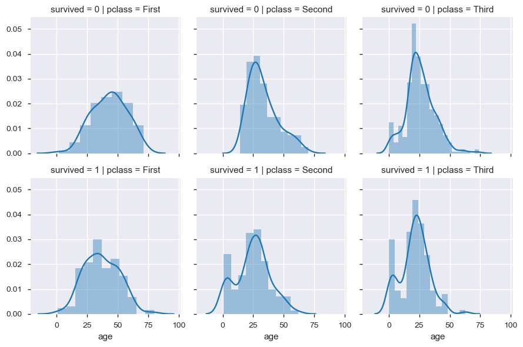

```python
#Survived with pclass and age
g = sns.FacetGrid(titanicData, row='survived', col='pclass')
g.map(sns.distplot, "age")
plt.show()
```

Based on above pivot table we can clearly see majorly females were servived while comparing to males accross the age groups. Also the ratio of survival was more on pclass 1 comparing to other classes

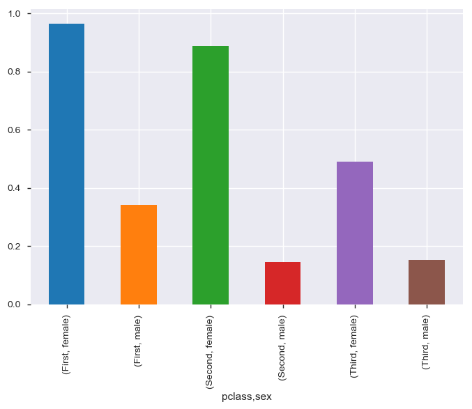

```python
class_sex_grouping['survived'].plot.bar()
```

[figure not shown]

```python
fig = plt.figure(figsize=(25, 10))
sns.violinplot(x='sex', y='age',
               hue='survived', data=titanicData,
               split=True,
               palette={0: "r", 1: "g"}
              );
plt.xlabel('Age',{'fontname':'Arial', 'size':'22'})
plt.ylabel('Sex',{'fontname':'Arial', 'size':'22'})
plt.show()
```

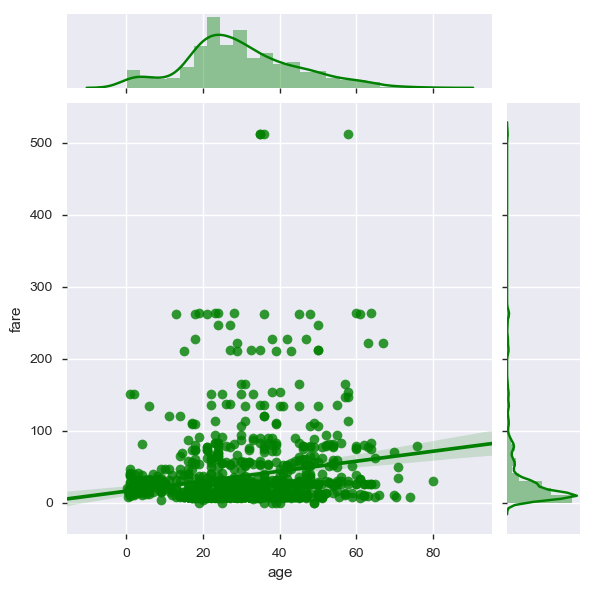

```python
sns.jointplot(data=titanicData, x='age', y='fare', kind='reg', color='g')
plt.show()
```

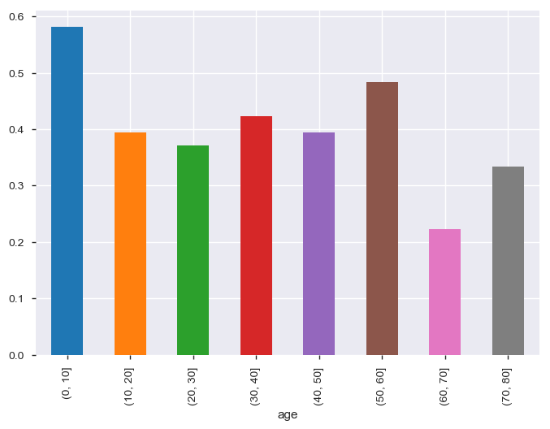

```python
#Plot graph for survived passengers by grouping them with age
group_by_age = pd.cut(titanicData["age"], np.arange(0, 90, 10))
age_grouping = titanicData.groupby(group_by_age).mean()
age_grouping['survived'].plot.bar()
```

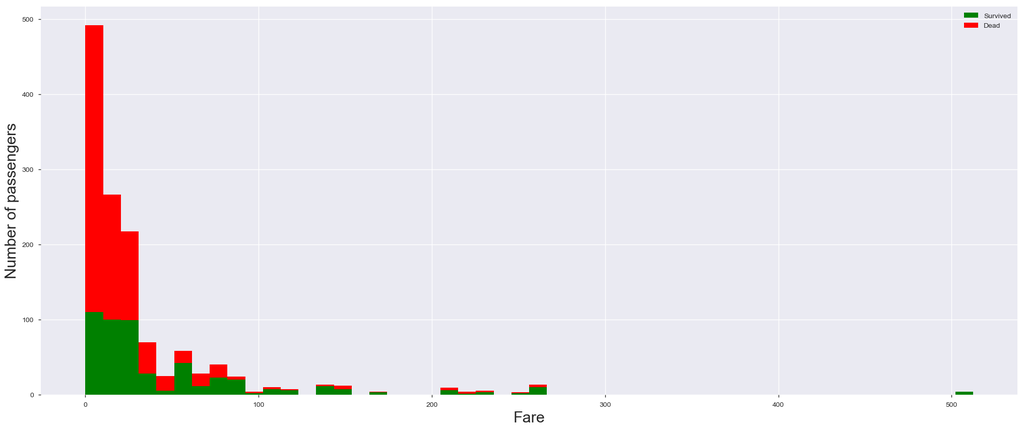

```python
#now focus on the Fare ticket of each passenger and see how it could impact the survival.
figure = plt.figure(figsize=(25, 10))
plt.hist([titanicData[titanicData['survived'] == 1]['fare'], titanicData[titanicData['survived'] == 0]['fare']],
         stacked=True, color = ['g','r'],
         bins = 50, label = ['Survived','Dead'])
plt.xlabel('Fare',{'fontname':'Arial', 'size':'22'})
plt.ylabel('Number of passengers',{'fontname':'Arial', 'size':'22'})
plt.legend();
```

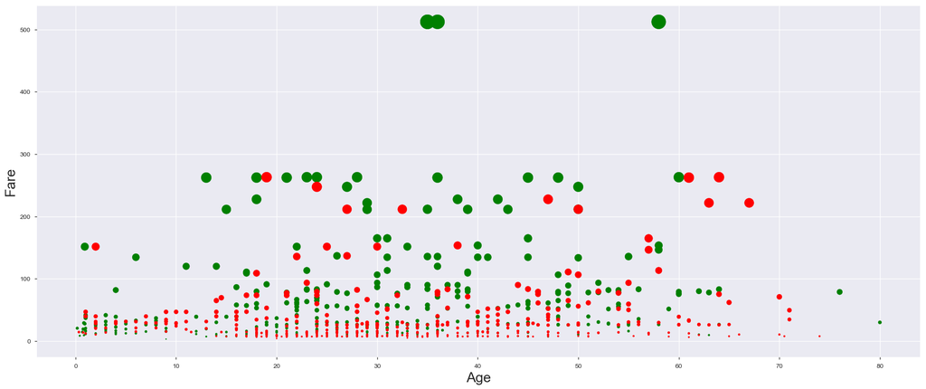

```python
#now combine the age, the fare and the survival on a single chart.
plt.figure(figsize=(25, 10))
ax = plt.subplot()
plt.xlabel('Age',{'fontname':'Arial', 'size':'22'})
plt.ylabel('Fare',{'fontname':'Arial', 'size':'22'})
ax.scatter(titanicData[titanicData['survived'] == 1]['age'], titanicData[titanicData['survived'] == 1]['fare'],
           c='green', s=titanicData[titanicData['survived'] == 1]['fare'])
ax.scatter(titanicData[titanicData['survived'] == 0]['age'], titanicData[titanicData['survived'] == 0]['fare'],
           c='red', s=titanicData[titanicData['survived'] == 0]['fare']);
```

The size of the circles is proportional to the ticket fare.

- the x-axis, we have the ages
- the y-axis, we consider the ticket fare.

We can observe different clusters:

- Large green dots between x=20 and x=45: adults with the largest ticket fares
- Small red dots between x=10 and x=45, adults from lower classes on the boat
- Small greed dots between x=0 and x=7: these are the children that were saved

[figure not shown]

```python
#the ticket fare correlates with the class
ax = plt.subplot()
titanicData.groupby('pclass').mean()['fare'].plot(kind='bar', figsize=(25, 10), ax = ax)
plt.xlabel('Average fare',{'fontname':'Arial', 'size':'22'})
plt.ylabel('PClass',{'fontname':'Arial', 'size':'22'})
plt.show()
```

[figure not shown]

```python
#now see how the embarkation site affects the survival.
fig = plt.figure(figsize=(25, 10))
sns.violinplot(x='embarked', y='fare', hue='survived', data=titanicData, split=True, palette={0: "r", 1: "g"})
plt.xlabel('Fare',{'fontname':'Arial', 'size':'22'})
plt.ylabel('embarked',{'fontname':'Arial', 'size':'22'})
plt.show()
```

```python
# using pivot table with survived, fare, pclass, sex and boat
pd.crosstab(titanicData['boat'],[titanicData['sex'],titanicData['pclass']],
            margins=True, margins_name="Total").T.style.background_gradient(cmap='summer_r')
```

| sex | boat pclass | 2 | 1 | 10 | 11 | 12 | 13 | 13 15 | 13 15 B | 14 | 15 | 15 16 | 16 | 2 | 3 | 4 | 5 | 5 7 | 5 9 | 6 | 7 | 8 | 8 10 | 9 | A | B | C | C D | D | … |
| --- | --- | --- | --- | --- | --- | --- | --- | --- | --- | --- | --- | --- | --- | --- | --- | --- | --- | --- | --- | --- | --- | --- | --- | --- | --- | --- | --- | --- | --- | --- |
| female | First | 1 | 2 | 8 | 4 | 0 | 0 | 0 | 0 | 4 | 0 | 0 | 0 | 6 | 13 | 22 | 14 | 1 | 0 | 18 | 11 | 23 | 1 | 4 | 0 | 0 | 0 | 0 | 6 | … |
|  | Second | 0 | 0 | 12 | 13 | 16 | 7 | 0 | 0 | 19 | 0 | 0 | 3 | 0 | 0 | 4 | 0 | 0 | 0 | 0 | 0 | 0 | 0 | 12 | 0 | 0 | 0 | 0 | 0 | … |
|  | Third | 0 | 0 | 4 | 1 | 1 | 18 | 0 | 0 | 2 | 13 | 1 | 18 | 3 | 0 | 0 | 0 | 0 | 0 | 0 | 0 | 0 | 0 | 0 | 2 | 0 | 24 | 1 | 7 | … |
| male | First | 0 | 3 | 0 | 2 | 0 | 1 | 0 | 0 | 1 | 1 | 0 | 0 | 0 | 13 | 2 | 13 | 1 | 1 | 1 | 11 | 0 | 0 | 2 | 3 | 3 | 2 | 0 | 3 | … |
|  | Second | 0 | 0 | 3 | 1 | 1 | 5 | 0 | 0 | 4 | 1 | 0 | 0 | 0 | 0 | 3 | 0 | 0 | 0 | 0 | 1 | 0 | 0 | 4 | 0 | 1 | 0 | 0 | 2 | … |
|  | Third | 0 | 0 | 2 | 4 | 1 | 8 | 2 | 1 | 3 | 22 | 0 | 2 | 3 | 0 | 0 | 0 | 0 | 0 | 1 | 0 | 0 | 0 | 3 | 6 | 5 | 12 | 1 | 2 | … |
| Total |  | 1 | 5 | 29 | 25 | 19 | 39 | 2 | 1 | 33 | 37 | 1 | 23 | 12 | 26 | 31 | 27 | 2 | 1 | 20 | 23 | 23 | 1 | 25 | 11 | 9 | 38 | 2 | 20 | … |

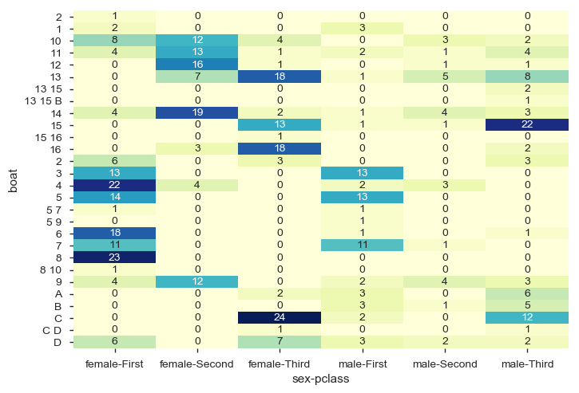

```python
sns.heatmap(pd.crosstab(titanicData['boat'],[titanicData['sex'],titanicData['pclass']]),
            cmap="YlGnBu", annot=True, cbar=False)
```

This shows that the Female passengers with pclass 1 has used maximum number of boats 138 comparing to other passengers.

# Feature Engginering

```python
featureEngData = titanicData
featureEngData.info()
featureEngData.shape
```

```
<class 'pandas.core.frame.DataFrame'>
RangeIndex: 1309 entries, 0 to 1308
Data columns (total 14 columns):
pclass       1309 non-null object
survived     1309 non-null int64
name         1309 non-null object
sex          1309 non-null object
age          1046 non-null float64
sibsp        1309 non-null int64
parch        1309 non-null int64
ticket       1309 non-null object
fare         1308 non-null float64
cabin        295 non-null object
embarked     1307 non-null object
boat         486 non-null object
body         121 non-null float64
home.dest    745 non-null object
dtypes: float64(3), int64(3), object(8)
memory usage: 143.2+ KB
```

```
(1309, 14)
```

## Extracting the passenger titles

```python
Title_Dictionary = {
    "Capt": "Officer",
    "Col": "Officer",
    "Major": "Officer",
    "Jonkheer": "Royalty",
    "Don": "Royalty",
    "Sir" : "Royalty",
    "Dr": "Officer",
    "Rev": "Officer",
    "the Countess":"Royalty",
    "Mme": "Mrs",
    "Mlle": "Miss",
    "Ms": "Mrs",
    "Mr" : "Mr",
    "Mrs" : "Mrs",
    "Miss" : "Miss",
    "Master" : "Master",
    "Lady" : "Royalty"
}

def get_titles():
    # we extract the title from each name
    featureEngData['title'] = featureEngData['name'].map(lambda name:name.split(',')[1].split('.')[0].strip())

    # a map of more aggregated title we map each title
    featureEngData['title'] = featureEngData.title.map(Title_Dictionary)
    return featureEngData
```

```python
featureEngData = get_titles()
featureEngData.head()
```

|  | pclass | survived | name | sex | age | sibsp | parch | ticket | fare | cabin | embarked | boat | body | home.dest | title |
| --- | --- | --- | --- | --- | --- | --- | --- | --- | --- | --- | --- | --- | --- | --- | --- |
| 0 | First | 1 | Allen, Miss. Elisabeth Walton | female | 29.0000 | 0 | 0 | 24160 | 211.3375 | B5 | Southampton | 2 | NaN | St Louis, MO | Miss |
| 1 | First | 1 | Allison, Master. Hudson Trevor | male | 0.9167 | 1 | 2 | 113781 | 151.5500 | C22 C26 | Southampton | 11 | NaN | Montreal, PQ / Chesterville, ON | Master |
| 2 | First | 0 | Allison, Miss. Helen Loraine | female | 2.0000 | 1 | 2 | 113781 | 151.5500 | C22 C26 | Southampton | NaN | NaN | Montreal, PQ / Chesterville, ON | Miss |
| 3 | First | 0 | Allison, Mr. Hudson Joshua Creighton | male | 30.0000 | 1 | 2 | 113781 | 151.5500 | C22 C26 | Southampton | NaN | 135.0 | Montreal, PQ / Chesterville, ON | Mr |
| 4 | First | 0 | Allison, Mrs. Hudson J C (Bessie Waldo Daniels) | female | 25.0000 | 1 | 2 | 113781 | 151.5500 | C22 C26 | Southampton | NaN | NaN | Montreal, PQ / Chesterville, ON | Mrs |

```python
pd.crosstab(featureEngData['title'],featureEngData['sex']).T.style.background_gradient(cmap='summer_r')
```

| title sex | Master | Miss | Mr | Mrs | Officer | Royalty |
| --- | --- | --- | --- | --- | --- | --- |
| female | 0 | 262 | 0 | 200 | 1 | 2 |
| male | 61 | 0 | 757 | 0 | 22 | 3 |

```python
# check if the titles have been filled correctly.
featureEngData[featureEngData['title'].isnull()]
```

|  | pclass | survived | name | sex | age | sibsp | parch | ticket | fare | cabin | embarked | boat | body | home.dest | title |
| --- | --- | --- | --- | --- | --- | --- | --- | --- | --- | --- | --- | --- | --- | --- | --- |
| 218 | First | 1 | Oliva y Ocana, Dona. Fermina | female | 39.0 | 0 | 0 | PC 17758 | 108.9 | C105 | Cherbourg | 8 | NaN | NaN | NaN |

There is indeed a NaN value in the line 218. In fact the corresponding name is Oliva y Ocana, Dona. Fermina. This title was not encoutered in the train dataset.

```python
# encoding in dummy variable
titles_dummies = pd.get_dummies(featureEngData['title'], prefix='Title')
featureEngData = pd.concat([featureEngData, titles_dummies], axis=1)
featureEngData.head()
```

|  | pclass | survived | name | sex | age | sibsp | parch | ticket | fare | cabin | ... | boat | body | home.dest | title | Title_Master | Title_Miss | Title_Mr | Title_Mrs | Title_Officer | Title_Royalty |
| --- | --- | --- | --- | --- | --- | --- | --- | --- | --- | --- | --- | --- | --- | --- | --- | --- | --- | --- | --- | --- | --- |
| 0 | First | 1 | Allen, Miss. Elisabeth Walton | female | 29.0000 | 0 | 0 | 24160 | 211.3375 | B5 | ... | 2 | NaN | St Louis, MO | Miss | 0 | 1 | 0 | 0 | 0 | 0 |
| 1 | First | 1 | Allison, Master. Hudson Trevor | male | 0.9167 | 1 | 2 | 113781 | 151.5500 | C22 C26 | ... | 11 | NaN | Montreal, PQ / Chesterville, ON | Master | 1 | 0 | 0 | 0 | 0 | 0 |
| 2 | First | 0 | Allison, Miss. Helen Loraine | female | 2.0000 | 1 | 2 | 113781 | 151.5500 | C22 C26 | ... | NaN | NaN | Montreal, PQ / Chesterville, ON | Miss | 0 | 1 | 0 | 0 | 0 | 0 |
| 3 | First | 0 | Allison, Mr. Hudson Joshua Creighton | male | 30.0000 | 1 | 2 | 113781 | 151.5500 | C22 C26 | ... | NaN | 135.0 | Montreal, PQ / Chesterville, ON | Mr | 0 | 0 | 1 | 0 | 0 | 0 |
| 4 | First | 0 | Allison, Mrs. Hudson J C (Bessie Waldo Daniels) | female | 25.0000 | 1 | 2 | 113781 | 151.5500 | C22 C26 | ... | NaN | NaN | Montreal, PQ / Chesterville, ON | Mrs | 0 | 0 | 0 | 1 | 0 | 0 |

5 rows × 21 columns

## processing for age

```python
print (featureEngData.iloc[:1309].age.isnull().sum())
```

```
263
```

Processing the ages as we have seen age has 263 / 20.1% missing values Missing. As this is large number of missing data and replacing them with mean, median will not give proper outcome, since the age may differ by groups and categories of passengers. Let's group the age with Sex, PClass and Newly added column Title

```python
bins = [0, 12, 17, 60, np.inf]
labels = ['child', 'teenager', 'adult', 'elder']
age_groups = pd.cut(featureEngData.age, bins, labels=labels)
featureEngData['age_group'] = age_groups
featureEngData.pivot_table(index='embarked', columns='age_group', aggfunc=np.median).fare
```

| age_group embarked | child | teenager | adult | elder |
| --- | --- | --- | --- | --- |
| Cherbourg | 17.2646 | 14.45420 | 55.4417 | 68.61460 |
| Queenstown | 29.1250 | 7.74165 | 7.7500 | 8.71875 |
| Southampton | 26.0000 | 18.00000 | 13.0000 | 26.55000 |

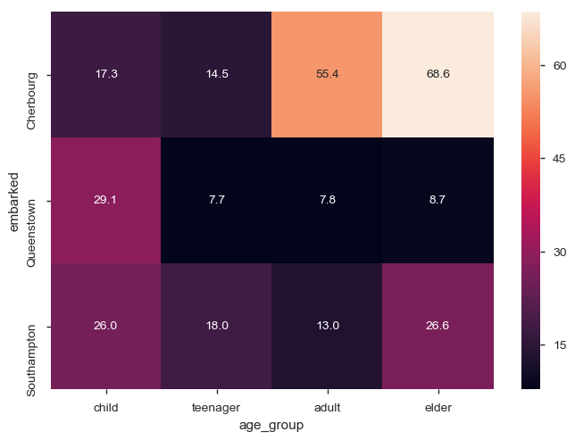

```python
df = featureEngData.pivot_table(index='embarked', columns='age_group', values='fare', aggfunc=np.median)
sns.heatmap(df, annot=True, fmt=".1f")
plt.show()
```

```python
#Now lets see by grouping function for pclass, title sex:
print(featureEngData.groupby(['sex','pclass','title'])['age'].count())
```

```
sex     pclass  title
female  First   Miss        61
                Mrs         68
                Officer      1
                Royalty      2
        Second  Miss        48
                Mrs         55
        Third   Miss       103
                Mrs         49
male    First   Master       5
                Mr         132
                Officer     11
                Royalty      3
        Second  Master      11
                Mr         137
                Officer     10
        Third   Master      37
                Mr         312
Name: age, dtype: int64
```

```python
#Now lets see by grouping function for both class, title sex:

grouped_train = featureEngData.iloc[:1309].groupby(['pclass','title','sex'])
grouped_median_train = grouped_train.median()
grouped_median_train = grouped_median_train.reset_index()[['sex', 'pclass', 'title', 'age']]

def fill_age(row):
    condition = (
        (grouped_median_train['sex'] == row['sex']) &
        (grouped_median_train['title'] == row['title']) &
        (grouped_median_train['pclass'] == row['pclass'])
    )
    return grouped_median_train[condition]['age'].values[0]

def process_age():
    # a function that fills the missing values of the Age variable
    featureEngData['age'] = featureEngData.apply(lambda row: fill_age(row) if np.isnan(row['age']) else row['age'], axis=1)
    return featureEngData
```

```python
featureEngData = process_age()
featureEngData.head()
```

|  | pclass | survived | name | sex | age | sibsp | parch | ticket | fare | cabin | ... | body | home.dest | title | Title_Master | Title_Miss | Title_Mr | Title_Mrs | Title_Officer | Title_Royalty | age_group |
| --- | --- | --- | --- | --- | --- | --- | --- | --- | --- | --- | --- | --- | --- | --- | --- | --- | --- | --- | --- | --- | --- |
| 0 | First | 1 | Allen, Miss. Elisabeth Walton | female | 29.0000 | 0 | 0 | 24160 | 211.3375 | B5 | ... | NaN | St Louis, MO | Miss | 0 | 1 | 0 | 0 | 0 | 0 | adult |
| 1 | First | 1 | Allison, Master. Hudson Trevor | male | 0.9167 | 1 | 2 | 113781 | 151.5500 | C22 C26 | ... | NaN | Montreal, PQ / Chesterville, ON | Master | 1 | 0 | 0 | 0 | 0 | 0 | child |
| 2 | First | 0 | Allison, Miss. Helen Loraine | female | 2.0000 | 1 | 2 | 113781 | 151.5500 | C22 C26 | ... | NaN | Montreal, PQ / Chesterville, ON | Miss | 0 | 1 | 0 | 0 | 0 | 0 | child |
| 3 | First | 0 | Allison, Mr. Hudson Joshua Creighton | male | 30.0000 | 1 | 2 | 113781 | 151.5500 | C22 C26 | ... | 135.0 | Montreal, PQ / Chesterville, ON | Mr | 0 | 0 | 1 | 0 | 0 | 0 | adult |
| 4 | First | 0 | Allison, Mrs. Hudson J C (Bessie Waldo Daniels) | female | 25.0000 | 1 | 2 | 113781 | 151.5500 | C22 C26 | ... | NaN | Montreal, PQ / Chesterville, ON | Mrs | 0 | 0 | 0 | 1 | 0 | 0 | adult |

5 rows × 22 columns

```python
print (featureEngData.iloc[:1309].age.isnull().sum())
```

```
0
```

Perfect. The missing ages have been replaced.

```python
pd.crosstab(featureEngData['sibsp'],featureEngData['pclass']).style.background_gradient('summer_r')
```

| pclass sibsp | First | Second | Third |
| --- | --- | --- | --- |
| 0 | 198 | 182 | 511 |
| 1 | 113 | 82 | 124 |
| 2 | 8 | 12 | 22 |
| 3 | 4 | 1 | 15 |
| 4 | 0 | 0 | 22 |
| 5 | 0 | 0 | 6 |
| 8 | 0 | 0 | 9 |

```python
pd.crosstab(featureEngData['sex'],featureEngData['boat']).style.background_gradient('summer_r')
```

| boat sex | 2 | 1 | 10 | 11 | 12 | 13 | 13 15 | 13 15 B | 14 | 15 | 15 16 | 16 | 2 | 3 | 4 | 5 | 5 7 | 5 9 | 6 | 7 | 8 | 8 10 | 9 | A | B | C | C D | D |
| --- | --- | --- | --- | --- | --- | --- | --- | --- | --- | --- | --- | --- | --- | --- | --- | --- | --- | --- | --- | --- | --- | --- | --- | --- | --- | --- | --- | --- |
| female | 1 | 2 | 24 | 18 | 17 | 25 | 0 | 0 | 25 | 13 | 1 | 21 | 9 | 13 | 26 | 14 | 1 | 0 | 18 | 11 | 23 | 1 | 16 | 2 | 0 | 24 | 1 | 13 |
| male | 0 | 3 | 5 | 7 | 2 | 14 | 2 | 1 | 8 | 24 | 0 | 2 | 3 | 13 | 5 | 13 | 1 | 1 | 2 | 12 | 0 | 0 | 9 | 9 | 9 | 14 | 1 | 7 |

```python
pd.crosstab(featureEngData['title'],featureEngData['boat'], margins=True,
            margins_name="Total").style.background_gradient('summer_r')
```

| boat title | 2 | 1 | 10 | 11 | 12 | 13 | 13 15 | 13 15 B | 14 | 15 | 15 16 | 16 | 2 | 3 | 4 | 5 | 5 7 | 5 9 | 6 | 7 | 8 | 8 10 | 9 | A | B | C | C D | D | Total |
| --- | --- | --- | --- | --- | --- | --- | --- | --- | --- | --- | --- | --- | --- | --- | --- | --- | --- | --- | --- | --- | --- | --- | --- | --- | --- | --- | --- | --- | --- |
| Master | 0 | 0 | 3 | 3 | 0 | 2 | 0 | 0 | 3 | 2 | 0 | 1 | 2 | 1 | 5 | 1 | 0 | 0 | 0 | 0 | 0 | 0 | 0 | 0 | 0 | 5 | 1 | 2 | 31 |
| Miss | 1 | 1 | 11 | 10 | 11 | 19 | 0 | 0 | 11 | 8 | 1 | 18 | 4 | 6 | 13 | 3 | 0 | 0 | 6 | 3 | 11 | 1 | 9 | 0 | 0 | 16 | 0 | 6 | 169 |
| Mr | 0 | 2 | 2 | 4 | 2 | 11 | 2 | 1 | 5 | 22 | 0 | 1 | 1 | 10 | 0 | 11 | 1 | 1 | 1 | 12 | 0 | 0 | 9 | 9 | 8 | 9 | 0 | 5 | 129 |
| Mrs | 0 | 0 | 13 | 8 | 6 | 6 | 0 | 0 | 14 | 5 | 0 | 3 | 5 | 7 | 13 | 11 | 1 | 0 | 12 | 8 | 9 | 0 | 7 | 2 | 0 | 8 | 1 | 7 | 146 |
| Officer | 0 | 0 | 0 | 0 | 0 | 1 | 0 | 0 | 0 | 0 | 0 | 0 | 0 | 2 | 0 | 1 | 0 | 0 | 1 | 0 | 1 | 0 | 0 | 0 | 1 | 0 | 0 | 0 | 7 |
| Royalty | 0 | 2 | 0 | 0 | 0 | 0 | 0 | 0 | 0 | 0 | 0 | 0 | 0 | 0 | 0 | 0 | 0 | 0 | 0 | 0 | 1 | 0 | 0 | 0 | 0 | 0 | 0 | 0 | 3 |
| Total | 1 | 5 | 29 | 25 | 19 | 39 | 2 | 1 | 33 | 37 | 1 | 23 | 12 | 26 | 31 | 27 | 2 | 1 | 20 | 23 | 22 | 1 | 25 | 11 | 9 | 38 | 2 | 20 | 485 |

Above details shows that majortity of boats were provided for female passangers compare to males

```python
pd.crosstab(featureEngData['home.dest'],featureEngData['sex']).T.style.background_gradient('summer_r')
```

| home.dest sex | ?Havana, Cuba | Aberdeen / Portland, OR | Albany, NY | Altdorf, Switzerland | Amenia, ND | Antwerp, Belgium / Stanton, OH | Argentina | Asarum, Sweden Brooklyn, NY | Ascot, Berkshire / Rochester, NY | Auburn, NY | Aughnacliff, Co Longford, Ireland New York, NY | Australia Fingal, ND | Austria | Austria Niagara Falls, NY | Austria-Hungary | Austria-Hungary / Germantown, Philadelphia, PA | Bangkok, Thailand / Roseville, IL | Barcelona, Spain / Havana, Cuba | Barre, Co Washington, VT | Basel, Switzerland | Bath, England / Massachusetts | Bayside, Queens, NY | Belfast | Belfast, NI | Belgium Montreal, PQ | Belgium Detroit, MI | Belmont, MA | Bennington, VT | Bergen, Norway | … |
| --- | --- | --- | --- | --- | --- | --- | --- | --- | --- | --- | --- | --- | --- | --- | --- | --- | --- | --- | --- | --- | --- | --- | --- | --- | --- | --- | --- | --- | --- | --- |
| female | 0 | 2 | 0 | 1 | 1 | 0 | 0 | 0 | 0 | 0 | 0 | 0 | 0 | 0 | 0 | 0 | 1 | 2 | 0 | 0 | 1 | 1 | 0 | 0 | 1 | 0 | 1 | 0 | 0 | … |
| male | 1 | 0 | 1 | 1 | 1 | 1 | 1 | 1 | 1 | 1 | 1 | 1 | 4 | 1 | 1 | 1 | 2 | 0 | 1 | 2 | 0 | 0 | 7 | 1 | 0 | 1 | 0 | 1 | 1 | … |

## processing for fare

```python
print (featureEngData.iloc[:1309].fare.isnull().sum())
```

```
1
```

```python
# there's one missing fare value - replacing it with the mean.
featureEngData.fare.fillna(featureEngData.iloc[:1309].fare.mean(), inplace=True)
print (featureEngData.iloc[:1309].fare.isnull().sum())
```

```
0
```

## processing for Embarked

```python
print (featureEngData.iloc[:1309].embarked.isnull().sum())
```

```
2
```

```python
# two missing embarked values - filling them with the most frequent one in the featureEngData set(S)
featureEngData1  = featureEngData.embarked.fillna('Southampton', inplace=True)
print('Counts of Labels')
featureEngData.groupby("embarked").size()
```

```
Counts of Labels
```

```
embarked
Cherbourg      270
Queenstown     123
Southampton    916
dtype: int64
```

```python
# dummy encoding for embarked values
embarked_dummies = pd.get_dummies(featureEngData['embarked'], prefix='Embarked')
featureEngData = pd.concat([featureEngData, embarked_dummies], axis=1)
featureEngData.head()
featureEngData.shape
```

|  | pclass | survived | name | sex | age | sibsp | parch | ticket | fare | cabin | ... | Title_Master | Title_Miss | Title_Mr | Title_Mrs | Title_Officer | Title_Royalty | age_group | Embarked_Cherbourg | Embarked_Queenstown | Embarked_Southampton |
| --- | --- | --- | --- | --- | --- | --- | --- | --- | --- | --- | --- | --- | --- | --- | --- | --- | --- | --- | --- | --- | --- |
| 0 | First | 1 | Allen, Miss. Elisabeth Walton | female | 29.0000 | 0 | 0 | 24160 | 211.3375 | B5 | ... | 0 | 1 | 0 | 0 | 0 | 0 | adult | 0 | 0 | 1 |
| 1 | First | 1 | Allison, Master. Hudson Trevor | male | 0.9167 | 1 | 2 | 113781 | 151.5500 | C22 C26 | ... | 1 | 0 | 0 | 0 | 0 | 0 | child | 0 | 0 | 1 |
| 2 | First | 0 | Allison, Miss. Helen Loraine | female | 2.0000 | 1 | 2 | 113781 | 151.5500 | C22 C26 | ... | 0 | 1 | 0 | 0 | 0 | 0 | child | 0 | 0 | 1 |
| 3 | First | 0 | Allison, Mr. Hudson Joshua Creighton | male | 30.0000 | 1 | 2 | 113781 | 151.5500 | C22 C26 | ... | 0 | 0 | 1 | 0 | 0 | 0 | adult | 0 | 0 | 1 |
| 4 | First | 0 | Allison, Mrs. Hudson J C (Bessie Waldo Daniels) | female | 25.0000 | 1 | 2 | 113781 | 151.5500 | C22 C26 | ... | 0 | 0 | 0 | 1 | 0 | 0 | adult | 0 | 0 | 1 |

5 rows × 25 columns

```
(1309, 25)
```

## processing for cabin

```python
print (featureEngData.iloc[:1309].cabin.isnull().sum())
```

```
1014
```

```python
# replacing missing cabins with U (for Uknown)
featureEngData.cabin.fillna('U', inplace=True)
print (featureEngData.iloc[:1309].cabin.isnull().sum())
```

```
0
```

```python
#Takenfirst letter of name Cabin ex. C22
train_cabin = set()

for c in featureEngData.iloc[:1309]['cabin']:
    try:
        train_cabin.add(c[0])
    except:
        train_cabin.add('U')

print (train_cabin)
```

```
{'C', 'D', 'U', 'B', 'G', 'T', 'F', 'A', 'E'}
```

```python
# mapping each Cabin value with the cabin letter
featureEngData['cabin'] = featureEngData['cabin'].map(lambda C: C[0])

# dummy encoding ...
cabin_dummies = pd.get_dummies(featureEngData['cabin'], prefix='Cabin')

featureEngData = pd.concat([featureEngData, cabin_dummies], axis=1)
featureEngData.head()
featureEngData.shape
```

|  | pclass | survived | name | sex | age | sibsp | parch | ticket | fare | cabin | ... | Embarked_Southampton | Cabin_A | Cabin_B | Cabin_C | Cabin_D | Cabin_E | Cabin_F | Cabin_G | Cabin_T | Cabin_U |
| --- | --- | --- | --- | --- | --- | --- | --- | --- | --- | --- | --- | --- | --- | --- | --- | --- | --- | --- | --- | --- | --- |
| 0 | First | 1 | Allen, Miss. Elisabeth Walton | female | 29.0000 | 0 | 0 | 24160 | 211.3375 | B | ... | 1 | 0 | 1 | 0 | 0 | 0 | 0 | 0 | 0 | 0 |
| 1 | First | 1 | Allison, Master. Hudson Trevor | male | 0.9167 | 1 | 2 | 113781 | 151.5500 | C | ... | 1 | 0 | 0 | 1 | 0 | 0 | 0 | 0 | 0 | 0 |
| 2 | First | 0 | Allison, Miss. Helen Loraine | female | 2.0000 | 1 | 2 | 113781 | 151.5500 | C | ... | 1 | 0 | 0 | 1 | 0 | 0 | 0 | 0 | 0 | 0 |
| 3 | First | 0 | Allison, Mr. Hudson Joshua Creighton | male | 30.0000 | 1 | 2 | 113781 | 151.5500 | C | ... | 1 | 0 | 0 | 1 | 0 | 0 | 0 | 0 | 0 | 0 |
| 4 | First | 0 | Allison, Mrs. Hudson J C (Bessie Waldo Daniels) | female | 25.0000 | 1 | 2 | 113781 | 151.5500 | C | ... | 1 | 0 | 0 | 1 | 0 | 0 | 0 | 0 | 0 | 0 |

5 rows × 34 columns

```
(1309, 34)
```

```python
pd.crosstab(featureEngData['sex'],featureEngData['cabin'],margins=True,
            margins_name="Total").style.background_gradient('summer_r')
```

| cabin sex | A | B | C | D | E | F | G | T | U | Total |
| --- | --- | --- | --- | --- | --- | --- | --- | --- | --- | --- |
| female | 4 | 36 | 46 | 23 | 19 | 8 | 5 | 0 | 325 | 466 |
| male | 18 | 29 | 48 | 23 | 22 | 13 | 0 | 1 | 689 | 843 |
| Total | 22 | 65 | 94 | 46 | 41 | 21 | 5 | 1 | 1014 | 1309 |

## Processing for sex mapping string values to numerical one

```python
featureEngData['sex'] = featureEngData['sex'].map({'male':1, 'female':0})
featureEngData.head()
featureEngData.shape
```

|  | pclass | survived | name | sex | age | sibsp | parch | ticket | fare | cabin | ... | Embarked_Southampton | Cabin_A | Cabin_B | Cabin_C | Cabin_D | Cabin_E | Cabin_F | Cabin_G | Cabin_T | Cabin_U |
| --- | --- | --- | --- | --- | --- | --- | --- | --- | --- | --- | --- | --- | --- | --- | --- | --- | --- | --- | --- | --- | --- |
| 0 | First | 1 | Allen, Miss. Elisabeth Walton | 0 | 29.0000 | 0 | 0 | 24160 | 211.3375 | B | ... | 1 | 0 | 1 | 0 | 0 | 0 | 0 | 0 | 0 | 0 |
| 1 | First | 1 | Allison, Master. Hudson Trevor | 1 | 0.9167 | 1 | 2 | 113781 | 151.5500 | C | ... | 1 | 0 | 0 | 1 | 0 | 0 | 0 | 0 | 0 | 0 |
| 2 | First | 0 | Allison, Miss. Helen Loraine | 0 | 2.0000 | 1 | 2 | 113781 | 151.5500 | C | ... | 1 | 0 | 0 | 1 | 0 | 0 | 0 | 0 | 0 | 0 |
| 3 | First | 0 | Allison, Mr. Hudson Joshua Creighton | 1 | 30.0000 | 1 | 2 | 113781 | 151.5500 | C | ... | 1 | 0 | 0 | 1 | 0 | 0 | 0 | 0 | 0 | 0 |
| 4 | First | 0 | Allison, Mrs. Hudson J C (Bessie Waldo Daniels) | 0 | 25.0000 | 1 | 2 | 113781 | 151.5500 | C | ... | 1 | 0 | 0 | 1 | 0 | 0 | 0 | 0 | 0 | 0 |

5 rows × 34 columns

```
(1309, 34)
```

## processing for pclass

```python
print (featureEngData.iloc[:1309].pclass.isnull().sum())
```

```
0
```

```python
# encoding into 3 categories:
pclass_dummies = pd.get_dummies(featureEngData['pclass'], prefix="Pclass")
# adding dummy variable
featureEngData = pd.concat([featureEngData, pclass_dummies],axis=1)
featureEngData.head()
featureEngData.shape
```

|  | pclass | survived | name | sex | age | sibsp | parch | ticket | fare | cabin | ... | Cabin_C | Cabin_D | Cabin_E | Cabin_F | Cabin_G | Cabin_T | Cabin_U | Pclass_First | Pclass_Second | Pclass_Third |
| --- | --- | --- | --- | --- | --- | --- | --- | --- | --- | --- | --- | --- | --- | --- | --- | --- | --- | --- | --- | --- | --- |
| 0 | First | 1 | Allen, Miss. Elisabeth Walton | 0 | 29.0000 | 0 | 0 | 24160 | 211.3375 | B | ... | 0 | 0 | 0 | 0 | 0 | 0 | 0 | 1 | 0 | 0 |
| 1 | First | 1 | Allison, Master. Hudson Trevor | 1 | 0.9167 | 1 | 2 | 113781 | 151.5500 | C | ... | 1 | 0 | 0 | 0 | 0 | 0 | 0 | 1 | 0 | 0 |
| 2 | First | 0 | Allison, Miss. Helen Loraine | 0 | 2.0000 | 1 | 2 | 113781 | 151.5500 | C | ... | 1 | 0 | 0 | 0 | 0 | 0 | 0 | 1 | 0 | 0 |
| 3 | First | 0 | Allison, Mr. Hudson Joshua Creighton | 1 | 30.0000 | 1 | 2 | 113781 | 151.5500 | C | ... | 1 | 0 | 0 | 0 | 0 | 0 | 0 | 1 | 0 | 0 |
| 4 | First | 0 | Allison, Mrs. Hudson J C (Bessie Waldo Daniels) | 0 | 25.0000 | 1 | 2 | 113781 | 151.5500 | C | ... | 1 | 0 | 0 | 0 | 0 | 0 | 0 | 1 | 0 | 0 |

5 rows × 37 columns

```
(1309, 37)
```

```python
print('Counts of Labels')
featureEngData.groupby("pclass").size()
```

```
Counts of Labels
```

```
pclass
First     323
Second    277
Third     709
dtype: int64
```

## processing for ticket

```python
print (featureEngData.iloc[:1309].ticket.isnull().sum())
```

```
0
```

```python
NoneType = type(None)
IntType = type(int)
def cleanTicket(ticket):
    if type(ticket) == NoneType:
        return 'XXX'
    elif type(ticket) == int:
        return 'XXX'
    else:
        ticket = ticket.replace('.', '')
        ticket = ticket.replace('/', '')
        ticket = ticket.split()
        ticket = map(lambda t : t.strip(), ticket)
        ticket = list(filter(lambda t : not t.isdigit(), ticket))
        if len(ticket) > 0:
            return ticket[0]
        else:
            return 'XXX'
```

```python
# a function that extracts each prefix of the ticket, returns 'XXX' if no prefix (i.e the ticket is a digit)
tickets = set()
for t in featureEngData['ticket']:
    tickets.add(cleanTicket(t))
```

```python
# Extracting dummy variables from tickets:

featureEngData['ticket'] = featureEngData['ticket'].map(cleanTicket)
tickets_dummies = pd.get_dummies(featureEngData['ticket'], prefix='Ticket')
featureEngData = pd.concat([featureEngData, tickets_dummies], axis=1)
featureEngData.head()
featureEngData.shape
```

|  | pclass | survived | name | sex | age | sibsp | parch | ticket | fare | cabin | ... | Ticket_SOTONO2 | Ticket_SOTONOQ | Ticket_SP | Ticket_STONO | Ticket_STONO2 | Ticket_STONOQ | Ticket_SWPP | Ticket_WC | Ticket_WEP | Ticket_XXX |
| --- | --- | --- | --- | --- | --- | --- | --- | --- | --- | --- | --- | --- | --- | --- | --- | --- | --- | --- | --- | --- | --- |
| 0 | First | 1 | Allen, Miss. Elisabeth Walton | 0 | 29.0000 | 0 | 0 | XXX | 211.3375 | B | ... | 0 | 0 | 0 | 0 | 0 | 0 | 0 | 0 | 0 | 1 |
| 1 | First | 1 | Allison, Master. Hudson Trevor | 1 | 0.9167 | 1 | 2 | XXX | 151.5500 | C | ... | 0 | 0 | 0 | 0 | 0 | 0 | 0 | 0 | 0 | 1 |
| 2 | First | 0 | Allison, Miss. Helen Loraine | 0 | 2.0000 | 1 | 2 | XXX | 151.5500 | C | ... | 0 | 0 | 0 | 0 | 0 | 0 | 0 | 0 | 0 | 1 |
| 3 | First | 0 | Allison, Mr. Hudson Joshua Creighton | 1 | 30.0000 | 1 | 2 | XXX | 151.5500 | C | ... | 0 | 0 | 0 | 0 | 0 | 0 | 0 | 0 | 0 | 1 |
| 4 | First | 0 | Allison, Mrs. Hudson J C (Bessie Waldo Daniels) | 0 | 25.0000 | 1 | 2 | XXX | 151.5500 | C | ... | 0 | 0 | 0 | 0 | 0 | 0 | 0 | 0 | 0 | 1 |

5 rows × 74 columns

```
(1309, 74)
```

```python
print('Counts of Labels')
featureEngData.groupby("ticket").size()
```

```
Counts of Labels
```

```
ticket
A            1
A4          10
A5          28
AQ3          1
AQ4          1
AS           1
C            8
CA          68
CASOTON      1
FC           3
FCC          9
Fa           1
LINE         4
LP           1
PC          92
PP           4
PPP          2
SC           2
SCA3         1
SCA4         2
SCAH         5
SCOW         1
SCPARIS     14
SCParis      5
SOC          8
SOP          1
SOPP         7
SOTONO2      3
SOTONOQ     24
SP           1
STONO       14
STONO2       7
STONOQ       1
SWPP         2
WC          15
WEP          4
XXX        957
dtype: int64
```

## Introducing a new feature : the size of families

Below we are introduces 4 new features:

```python
# introducing a new feature : the size of families (including the passenger)
featureEngData['FamilySize'] = featureEngData['parch'] + featureEngData['sibsp'] + 1

# introducing other features based on the family size
featureEngData['Singleton'] = featureEngData['FamilySize'].map(lambda s: 1 if s == 1 else 0)
featureEngData['SmallFamily'] = featureEngData['FamilySize'].map(lambda s: 1 if 2 <= s <= 4 else 0)
featureEngData['LargeFamily'] = featureEngData['FamilySize'].map(lambda s: 1 if 5 <= s else 0)
featureEngData.head()
featureEngData.shape
```

|  | pclass | survived | name | sex | age | sibsp | parch | ticket | fare | cabin | ... | Ticket_STONO2 | Ticket_STONOQ | Ticket_SWPP | Ticket_WC | Ticket_WEP | Ticket_XXX | FamilySize | Singleton | SmallFamily | LargeFamily |
| --- | --- | --- | --- | --- | --- | --- | --- | --- | --- | --- | --- | --- | --- | --- | --- | --- | --- | --- | --- | --- | --- |
| 0 | First | 1 | Allen, Miss. Elisabeth Walton | 0 | 29.0000 | 0 | 0 | XXX | 211.3375 | B | ... | 0 | 0 | 0 | 0 | 0 | 1 | 1 | 1 | 0 | 0 |
| 1 | First | 1 | Allison, Master. Hudson Trevor | 1 | 0.9167 | 1 | 2 | XXX | 151.5500 | C | ... | 0 | 0 | 0 | 0 | 0 | 1 | 4 | 0 | 1 | 0 |
| 2 | First | 0 | Allison, Miss. Helen Loraine | 0 | 2.0000 | 1 | 2 | XXX | 151.5500 | C | ... | 0 | 0 | 0 | 0 | 0 | 1 | 4 | 0 | 1 | 0 |
| 3 | First | 0 | Allison, Mr. Hudson Joshua Creighton | 1 | 30.0000 | 1 | 2 | XXX | 151.5500 | C | ... | 0 | 0 | 0 | 0 | 0 | 1 | 4 | 0 | 1 | 0 |
| 4 | First | 0 | Allison, Mrs. Hudson J C (Bessie Waldo Daniels) | 0 | 25.0000 | 1 | 2 | XXX | 151.5500 | C | ... | 0 | 0 | 0 | 0 | 0 | 1 | 4 | 0 | 1 | 0 |

5 rows × 78 columns

```
(1309, 78)
```

```python
#Making copy of Feature Engginering dataset
featureEngData1 = featureEngData.copy()
```

## removing all duplicate and unused variables

```python
featureEngData1.drop('name', axis=1, inplace=True)
featureEngData1.drop('embarked', axis=1, inplace=True)
featureEngData1.drop('cabin', axis=1, inplace=True)
featureEngData1.drop('pclass',axis=1,inplace=True)
featureEngData1.drop('ticket', inplace=True, axis=1)
featureEngData1.drop('title', axis=1, inplace=True)
featureEngData1.drop('boat', axis=1, inplace=True)
featureEngData1.drop('body', axis=1, inplace=True)
featureEngData1.drop('home.dest', axis=1, inplace=True)
featureEngData1.drop('survived', axis=1, inplace=True)
featureEngData1.drop('age_group', axis=1, inplace=True)
```

```python
featureEngData1.head()
featureEngData1.columns
featureEngData1.shape
```

|  | sex | age | sibsp | parch | fare | Title_Master | Title_Miss | Title_Mr | Title_Mrs | Title_Officer | ... | Ticket_STONO2 | Ticket_STONOQ | Ticket_SWPP | Ticket_WC | Ticket_WEP | Ticket_XXX | FamilySize | Singleton | SmallFamily | LargeFamily |
| --- | --- | --- | --- | --- | --- | --- | --- | --- | --- | --- | --- | --- | --- | --- | --- | --- | --- | --- | --- | --- | --- |
| 0 | 0 | 29.0000 | 0 | 0 | 211.3375 | 0 | 1 | 0 | 0 | 0 | ... | 0 | 0 | 0 | 0 | 0 | 1 | 1 | 1 | 0 | 0 |
| 1 | 1 | 0.9167 | 1 | 2 | 151.5500 | 1 | 0 | 0 | 0 | 0 | ... | 0 | 0 | 0 | 0 | 0 | 1 | 4 | 0 | 1 | 0 |
| 2 | 0 | 2.0000 | 1 | 2 | 151.5500 | 0 | 1 | 0 | 0 | 0 | ... | 0 | 0 | 0 | 0 | 0 | 1 | 4 | 0 | 1 | 0 |
| 3 | 1 | 30.0000 | 1 | 2 | 151.5500 | 0 | 0 | 1 | 0 | 0 | ... | 0 | 0 | 0 | 0 | 0 | 1 | 4 | 0 | 1 | 0 |
| 4 | 0 | 25.0000 | 1 | 2 | 151.5500 | 0 | 0 | 0 | 1 | 0 | ... | 0 | 0 | 0 | 0 | 0 | 1 | 4 | 0 | 1 | 0 |

5 rows × 67 columns

```
Index(['sex', 'age', 'sibsp', 'parch', 'fare', 'Title_Master', 'Title_Miss',
       'Title_Mr', 'Title_Mrs', 'Title_Officer', 'Title_Royalty',
       'Embarked_Cherbourg', 'Embarked_Queenstown', 'Embarked_Southampton',
       'Cabin_A', 'Cabin_B', 'Cabin_C', 'Cabin_D', 'Cabin_E', 'Cabin_F',
       'Cabin_G', 'Cabin_T', 'Cabin_U', 'Pclass_First', 'Pclass_Second',
       'Pclass_Third', 'Ticket_A', 'Ticket_A4', 'Ticket_A5', 'Ticket_AQ3',
       'Ticket_AQ4', 'Ticket_AS', 'Ticket_C', 'Ticket_CA', 'Ticket_CASOTON',
       'Ticket_FC', 'Ticket_FCC', 'Ticket_Fa', 'Ticket_LINE', 'Ticket_LP',
       'Ticket_PC', 'Ticket_PP', 'Ticket_PPP', 'Ticket_SC', 'Ticket_SCA3',
       'Ticket_SCA4', 'Ticket_SCAH', 'Ticket_SCOW', 'Ticket_SCPARIS',
       'Ticket_SCParis', 'Ticket_SOC', 'Ticket_SOP', 'Ticket_SOPP',
       'Ticket_SOTONO2', 'Ticket_SOTONOQ', 'Ticket_SP', 'Ticket_STONO',
       'Ticket_STONO2', 'Ticket_STONOQ', 'Ticket_SWPP', 'Ticket_WC',
       'Ticket_WEP', 'Ticket_XXX', 'FamilySize', 'Singleton', 'SmallFamily',
       'LargeFamily'],
      dtype='object')
```

```
(1309, 67)
```

```python
X = featureEngData1
y = featureEngData['survived'].values
```

# Now start building the models using this converted data

## Creating training dataset

```python
X_train, X_test, y_train, y_test = train_test_split(X,y,test_size=0.20, random_state=1)
X_train.shape
X_test.shape
y_train.shape
y_test.shape
type(X_train)
```

```
(1047, 67)
```

```
(262, 67)
```

```
(1047,)
```

```
(262,)
```

```
pandas.core.frame.DataFrame
```

## Creating Decision Tree

```python
from sklearn.tree import DecisionTreeClassifier
clf_dt = DecisionTreeClassifier(criterion="gini",max_depth=5)
clf_dt.fit (X_train, y_train)
classes = clf_dt.predict(X_test)
clf_dt.score (X_test, y_test)
```

```
DecisionTreeClassifier(class_weight=None, criterion='gini', max_depth=5,
            max_features=None, max_leaf_nodes=None,
            min_impurity_decrease=0.0, min_impurity_split=None,
            min_samples_leaf=1, min_samples_split=2,
            min_weight_fraction_leaf=0.0, presort=False, random_state=None,
            splitter='best')
```

```
0.8015267175572519
```

```python
import graphviz
from sklearn import tree
dot_data = tree.export_graphviz(clf_dt, out_file=None,
                               feature_names=X_train.columns,
                               class_names=['Default','Not'],
                               filled=True, rounded=True,
                               special_characters=True)
graph = graphviz.Source(dot_data)
graph
```

[figure not shown]

## Decision Tree - Precision and Recall

```python
#Precision and Recall
print('Accuracy Score')
print(metrics.accuracy_score(y_test,classes))
print('Precision/Recall Metrices')
print(metrics.classification_report(y_test,classes))
print('AUC')
print(metrics.roc_auc_score(y_test,classes))
```

```
Accuracy Score
0.8015267175572519
Precision/Recall Metrices
              precision    recall  f1-score   support

           0       0.78      0.93      0.85       156
           1       0.86      0.61      0.71       106

   micro avg       0.80      0.80      0.80       262
   macro avg       0.82      0.77      0.78       262
weighted avg       0.81      0.80      0.79       262

AUC
0.7713473633284954
```

## Decision Tree - ROC Chart

```
(0, 1)
```

```
(0, 1)
```

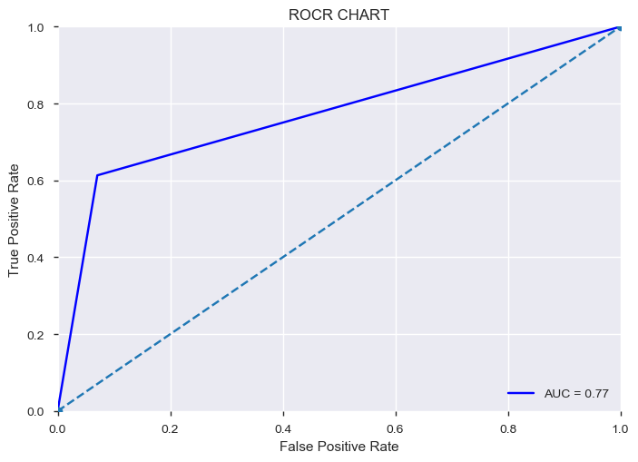

```python
#ROC Chart
fpr, tpr, th = roc_curve(y_test,classes)
roc_auc = metrics.auc(fpr,tpr)
import matplotlib.pyplot as plt
plt.title('ROCR CHART')
plt.plot(fpr,tpr,'b', label='AUC = %0.2f'% roc_auc)
plt.legend(loc='lower right')
plt.plot([0,1],[0,1],'o--')
plt.xlim([0,1])
plt.ylim([0,1])
plt.ylabel('True Positive Rate')
plt.xlabel('False Positive Rate')
plt.show()
```

## Decision Tree - Confusion Matrix

```
Confusion Matrix
```

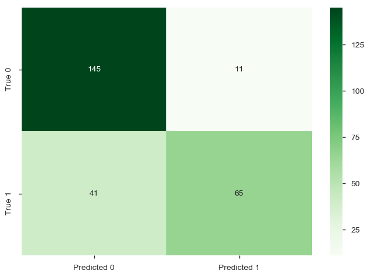

```python
#Confusion Matrix
print("Confusion Matrix")
cf = metrics.confusion_matrix(y_test,classes)
lbl1 = ["Predicted 0","Predicted 1"]
lbl2 = ["True 0", "True 1"]
sns.heatmap(cf, annot=True, cmap="Greens", fmt="d", xticklabels=lbl1, yticklabels=lbl2)
plt.show()
```

```python
feature_imp=pd.concat([pd.DataFrame(X_train.columns),pd.DataFrame(clf_dt.feature_importances_)],axis=1)
```

```python
feature_imp.columns=['Feature','Relative_Importance']
```

```python
feature_imp=feature_imp.sort_values('Relative_Importance',ascending=False)
```

```python
feature_imp.head(10)
```

|  | Feature | Relative_Importance |
| --- | --- | --- |
| 7 | Title_Mr | 0.528377 |
| 25 | Pclass_Third | 0.163026 |
| 1 | age | 0.075181 |
| 9 | Title_Officer | 0.059608 |
| 66 | LargeFamily | 0.050879 |
| 22 | Cabin_U | 0.042547 |
| 4 | fare | 0.031083 |
| 59 | Ticket_SWPP | 0.012354 |
| 60 | Ticket_WC | 0.010704 |
| 18 | Cabin_E | 0.010243 |

```python
decision_tree_accuracy_score = metrics.accuracy_score(y_test,classes)
print(decision_tree_accuracy_score)
```

```
0.8015267175572519
```

```python
#Applying the learnt model on the test dataset
y_pred_test = pd.DataFrame( { 'actual':  y_test,
                            'predicted': clf_dt.predict( X_test ) } )
y_pred_test.shape
y_pred_test.head(10)
```

```
(262, 2)
```

|  | actual | predicted |
| --- | --- | --- |
| 0 | 0 | 0 |
| 1 | 0 | 0 |
| 2 | 1 | 1 |
| 3 | 0 | 0 |
| 4 | 1 | 1 |
| 5 | 0 | 0 |
| 6 | 0 | 0 |
| 7 | 1 | 1 |
| 8 | 1 | 1 |
| 9 | 0 | 0 |

```python
#Generate Model Diagnostics
predictions = clf_dt.predict(X_test)
print("Total Cases : - ", predictions.size)

print("Positive cases in Test Data using Decision Tree : - ",predictions[y_test==1].shape[0])
print("Negative cases in Test Data using Decision Tree : - ",predictions[y_test==0].shape[0])
```

```
Total Cases : -  262
Positive cases in Test Data using Decision Tree : -  106
Negative cases in Test Data using Decision Tree : -  156
```

```python
param_grid = {'max_depth': np.arange(3, 11),
             'max_features': np.arange(3,11)}
```

```python
tree = GridSearchCV(DecisionTreeClassifier(), param_grid, cv = 10)
tree.fit(X_train, y_train)
```

```
GridSearchCV(cv=10, error_score='raise-deprecating',
       estimator=DecisionTreeClassifier(class_weight=None, criterion='gini', max_depth=None,
            max_features=None, max_leaf_nodes=None,
            min_impurity_decrease=0.0, min_impurity_split=None,
            min_samples_leaf=1, min_samples_split=2,
            min_weight_fraction_leaf=0.0, presort=False, random_state=None,
            splitter='best'),
       fit_params=None, iid='warn', n_jobs=None,
       param_grid={'max_depth': array([ 3,  4,  5,  6,  7,  8,  9, 10]), 'max_features': array([ 3,  4,  5,  6,  7,  8,  9, 10])},
       pre_dispatch='2*n_jobs', refit=True, return_train_score='warn',
       scoring=None, verbose=0)
```

```python
tree.best_params_
```

```
{'max_depth': 7, 'max_features': 10}
```

```python
tree.best_estimator_
```

```
DecisionTreeClassifier(class_weight=None, criterion='gini', max_depth=7,
            max_features=10, max_leaf_nodes=None,
            min_impurity_decrease=0.0, min_impurity_split=None,
            min_samples_leaf=1, min_samples_split=2,
            min_weight_fraction_leaf=0.0, presort=False, random_state=None,
            splitter='best')
```

```python
clf_tree = DecisionTreeClassifier( max_depth = 8, max_features=9 )
clf_tree.fit( X_train, y_train )
```

```
DecisionTreeClassifier(class_weight=None, criterion='gini', max_depth=8,
            max_features=9, max_leaf_nodes=None, min_impurity_decrease=0.0,
            min_impurity_split=None, min_samples_leaf=1,
            min_samples_split=2, min_weight_fraction_leaf=0.0,
            presort=False, random_state=None, splitter='best')
```

```python
clf_tree.feature_importances_
```

```
array([1.70436094e-01, 5.08112629e-02, 4.04801397e-03, 1.89905709e-02,
       2.62197408e-01, 1.22790622e-02, 0.00000000e+00, 1.42567852e-01,
       1.03466530e-01, 0.00000000e+00, 0.00000000e+00, 8.80226858e-03,
       5.93747537e-03, 8.85415912e-03, 3.64123757e-03, 7.17528719e-03,
       8.14428820e-03, 8.44095786e-03, 4.32986757e-03, 0.00000000e+00,
       0.00000000e+00, 0.00000000e+00, 7.97105260e-03, 6.94845980e-03,
       1.55893955e-02, 5.09690860e-02, 0.00000000e+00, 3.64123757e-04,
       2.86817482e-03, 0.00000000e+00, 0.00000000e+00, 0.00000000e+00,
       6.16496845e-04, 0.00000000e+00, 0.00000000e+00, 0.00000000e+00,
       6.62043194e-05, 0.00000000e+00, 0.00000000e+00, 0.00000000e+00,
       3.38368960e-03, 2.99866623e-04, 0.00000000e+00, 0.00000000e+00,
       0.00000000e+00, 0.00000000e+00, 0.00000000e+00, 0.00000000e+00,
       3.35442563e-03, 0.00000000e+00, 0.00000000e+00, 0.00000000e+00,
       0.00000000e+00, 0.00000000e+00, 0.00000000e+00, 0.00000000e+00,
       3.89371447e-03, 0.00000000e+00, 0.00000000e+00, 0.00000000e+00,
       1.53209484e-02, 0.00000000e+00, 7.73393472e-03, 1.58626353e-02,
       4.20032485e-03, 4.04351321e-02, 0.00000000e+00])
```

```python
clf_tree.predict(X_train)
```

```
array([0, 0, 1, ..., 0, 0, 0], dtype=int64)
```

## Logistic Regression

```python
from sklearn.linear_model import  LogisticRegression

log_model = LogisticRegression()
log_model.fit(X_train, y_train)
```

```
LogisticRegression(C=1.0, class_weight=None, dual=False, fit_intercept=True,
          intercept_scaling=1, max_iter=100, multi_class='warn',
          n_jobs=None, penalty='l2', random_state=None, solver='warn',
          tol=0.0001, verbose=0, warm_start=False)
```

```python
print('Coefficients: \n',log_model.coef_)
```

```
Coefficients:
 [[-1.07635714 -0.02923796 -0.36287666 -0.18139758  0.00241318  1.20066323
   0.38919303 -1.0520827   0.93020022 -0.78597604 -0.16459186  0.53183375
   0.11641469  0.03644472  0.45213407  0.26470675 -0.16795436  0.28017082
   0.81484566  0.45492057 -0.65531979 -0.25019644 -0.50861412  0.92818718
   0.31773015 -0.56122417  0.34733118 -0.38644332 -0.30159913 -0.47349522
   0.         -0.07115025  0.07910294  0.12729408 -0.14077329  0.22427147
  -0.24581731  0.         -0.16143796 -0.07107882 -0.25223422  0.55836521
  -0.03643891 -0.14077329 -0.1958045  -0.14167194 -0.36683408  0.
   0.52735129  0.02501333 -0.3485905   0.         -0.03674953  0.60006375
  -0.29362553 -0.08491817  1.25510901 -0.05012175  0.          1.30927712
  -0.52744074 -0.17273934  0.13125155  0.14041893  0.59895193  0.60918595
  -0.52344472]]
```

```python
#Find out key predictor of churn
coeff= pd.concat([pd.DataFrame(X.columns),pd.DataFrame(np.transpose(log_model.coef_))], axis=1)
coeff.columns=("Variable","Coeff")
coeff.sort_values("Variable",ascending=True)
```

|  | Variable | Coeff |
| --- | --- | --- |
| 14 | Cabin_A | 0.452134 |
| 15 | Cabin_B | 0.264707 |
| 16 | Cabin_C | -0.167954 |
| 17 | Cabin_D | 0.280171 |
| 18 | Cabin_E | 0.814846 |
| 19 | Cabin_F | 0.454921 |
| 20 | Cabin_G | -0.655320 |
| 21 | Cabin_T | -0.250196 |
| 22 | Cabin_U | -0.508614 |
| 11 | Embarked_Cherbourg | 0.531834 |
| 12 | Embarked_Queenstown | 0.116415 |
| 13 | Embarked_Southampton | 0.036445 |
| 63 | FamilySize | 0.140419 |
| 66 | LargeFamily | -0.523445 |
| 23 | Pclass_First | 0.928187 |
| 24 | Pclass_Second | 0.317730 |
| 25 | Pclass_Third | -0.561224 |
| 64 | Singleton | 0.598952 |
| 65 | SmallFamily | 0.609186 |
| 26 | Ticket_A | 0.347331 |
| 27 | Ticket_A4 | -0.386443 |
| 28 | Ticket_A5 | -0.301599 |
| 29 | Ticket_AQ3 | -0.473495 |
| 30 | Ticket_AQ4 | 0.000000 |
| 31 | Ticket_AS | -0.071150 |
| 32 | Ticket_C | 0.079103 |
| 33 | Ticket_CA | 0.127294 |
| 34 | Ticket_CASOTON | -0.140773 |
| 35 | Ticket_FC | 0.224271 |
| 36 | Ticket_FCC | -0.245817 |
| ... | ... | ... |
| 44 | Ticket_SCA3 | -0.195805 |
| 45 | Ticket_SCA4 | -0.141672 |
| 46 | Ticket_SCAH | -0.366834 |
| 47 | Ticket_SCOW | 0.000000 |
| 48 | Ticket_SCPARIS | 0.527351 |
| 49 | Ticket_SCParis | 0.025013 |
| 50 | Ticket_SOC | -0.348590 |
| 51 | Ticket_SOP | 0.000000 |
| 52 | Ticket_SOPP | -0.036750 |
| 53 | Ticket_SOTONO2 | 0.600064 |
| 54 | Ticket_SOTONOQ | -0.293626 |
| 55 | Ticket_SP | -0.084918 |
| 56 | Ticket_STONO | 1.255109 |
| 57 | Ticket_STONO2 | -0.050122 |
| 58 | Ticket_STONOQ | 0.000000 |
| 59 | Ticket_SWPP | 1.309277 |
| 60 | Ticket_WC | -0.527441 |
| 61 | Ticket_WEP | -0.172739 |
| 62 | Ticket_XXX | 0.131252 |
| 5 | Title_Master | 1.200663 |
| 6 | Title_Miss | 0.389193 |
| 7 | Title_Mr | -1.052083 |
| 8 | Title_Mrs | 0.930200 |
| 9 | Title_Officer | -0.785976 |
| 10 | Title_Royalty | -0.164592 |
| 1 | age | -0.029238 |
| 4 | fare | 0.002413 |
| 3 | parch | -0.181398 |
| 0 | sex | -1.076357 |
| 2 | sibsp | -0.362877 |

67 rows × 2 columns

```python
#Applying the learnt model on the test dataset
y_pred_test = pd.DataFrame( { 'actual':  y_test,
                            'predicted': log_model.predict( X_test ) } )
y_pred_test.shape
y_pred_test.head(10)
```

```
(262, 2)
```

|  | actual | predicted |
| --- | --- | --- |
| 0 | 0 | 0 |
| 1 | 0 | 0 |
| 2 | 1 | 1 |
| 3 | 0 | 0 |
| 4 | 1 | 1 |
| 5 | 0 | 0 |
| 6 | 0 | 0 |
| 7 | 1 | 1 |
| 8 | 1 | 1 |
| 9 | 0 | 0 |

```python
#Generate Model Diagnostics
predictions = log_model.predict(X_test)
print("Total Cases : - ", predictions.size)

print("Positive cases in Test Data using Logistic Regresion : - ",predictions[y_test==1].shape[0])
print("Negative cases in Test Data using Logistic Regresion : - ",predictions[y_test==0].shape[0])
```

```
Total Cases : -  262
Positive cases in Test Data using Logistic Regresion : -  106
Negative cases in Test Data using Logistic Regresion : -  156
```

## Logistic Regression - Precision and Recall

```python
#Precision and Recall
print('Accuracy Score')
logistic_reg_accuracy_score = round(metrics.accuracy_score(y_test,predictions),2)
print(logistic_reg_accuracy_score)
print('Precision/Recall Metrices')
print(metrics.classification_report(y_test,predictions))
print('AUC')
print(metrics.roc_auc_score(y_test,predictions))
```

```
Accuracy Score
0.85
Precision/Recall Metrices
              precision    recall  f1-score   support

           0       0.84      0.93      0.88       156
           1       0.88      0.74      0.80       106

   micro avg       0.85      0.85      0.85       262
   macro avg       0.86      0.83      0.84       262
weighted avg       0.85      0.85      0.85       262

AUC
0.8326681180454766
```

## Logistic Regression - ROC Chart

```
(0, 1)
```

```
(0, 1)
```

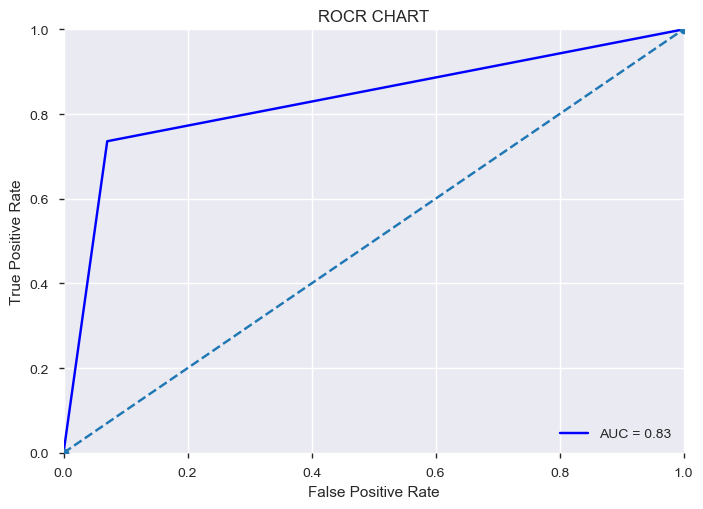

```python
#ROC Chart
fpr, tpr, th = roc_curve(y_test,predictions)
roc_auc = metrics.auc(fpr,tpr)
import matplotlib.pyplot as plt
plt.title('ROCR CHART')
plt.plot(fpr,tpr,'b', label='AUC = %0.2f'% roc_auc)
plt.legend(loc='lower right')
plt.plot([0,1],[0,1],'o--')
plt.xlim([0,1])
plt.ylim([0,1])
plt.ylabel('True Positive Rate')
plt.xlabel('False Positive Rate')
plt.show()
```

## Logistic Regression - Confusion Matrix

```
Confusion Matrix
```

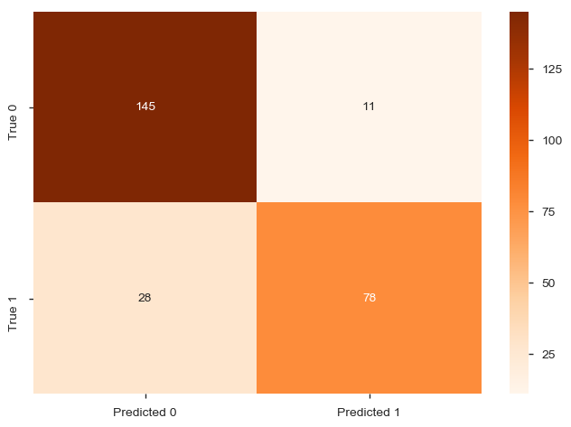

```python
#Confusion Matrix
print("Confusion Matrix")
cf = metrics.confusion_matrix(y_test,predictions)
lbl1 = ["Predicted 0","Predicted 1"]
lbl2 = ["True 0", "True 1"]
sns.heatmap(cf, annot=True, cmap="Oranges", fmt="d", xticklabels=lbl1, yticklabels=lbl2)
plt.show()
```

## Build SVM Model

```python
svm_clf = svm.SVC()
```

```python
#Fitting the model
svm_clf.fit(X_train, y_train)
```

```
SVC(C=1.0, cache_size=200, class_weight=None, coef0=0.0,
  decision_function_shape='ovr', degree=3, gamma='auto_deprecated',
  kernel='rbf', max_iter=-1, probability=False, random_state=None,
  shrinking=True, tol=0.001, verbose=False)
```

```python
#Applying the learnt model on the test dataset
y_pred_test = pd.DataFrame( { 'actual':  y_test,
                            'predicted': svm_clf.predict( X_test ) } )
y_pred_test.shape
y_pred_test.head(10)
```

```
(262, 2)
```

|  | actual | predicted |
| --- | --- | --- |
| 0 | 0 | 1 |
| 1 | 0 | 1 |
| 2 | 1 | 1 |
| 3 | 0 | 0 |
| 4 | 1 | 1 |
| 5 | 0 | 0 |
| 6 | 0 | 0 |
| 7 | 1 | 1 |
| 8 | 1 | 1 |
| 9 | 0 | 0 |

```python
#Generate Model Diagnostics
predictions = svm_clf.predict(X_test)
print("Total Cases : - ", predictions.size)

print("Positive cases in Test Data using SVM : - ",predictions[y_test==1].shape[0])
print("Negative cases in Test Data using SVM : - ",predictions[y_test==0].shape[0])
```

```
Total Cases : -  262
Positive cases in Test Data using SVM : -  106
Negative cases in Test Data using SVM : -  156
```

```python
#Generating accuracy score
metrics.accuracy_score(y_test, predictions)
```

```
0.6679389312977099
```

## SVM Model - ROC Chart

```
(0, 1)
```

```
(0, 1)
```

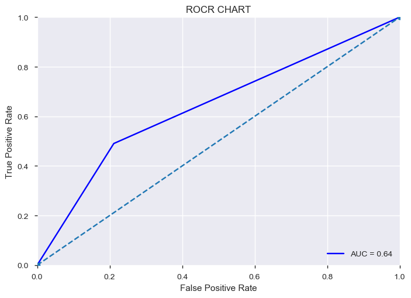

```python
#ROC Chart
fpr, tpr, th = roc_curve(y_test,predictions)
roc_auc = metrics.auc(fpr,tpr)
import matplotlib.pyplot as plt
plt.title('ROCR CHART')
plt.plot(fpr,tpr,'b', label='AUC = %0.2f'% roc_auc)
plt.legend(loc='lower right')
plt.plot([0,1],[0,1],'o--')
plt.xlim([0,1])
plt.ylim([0,1])
plt.ylabel('True Positive Rate')
plt.xlabel('False Positive Rate')
plt.show()
```

## SVM Model - Confusion Matrix

```
Confusion Matrix
```

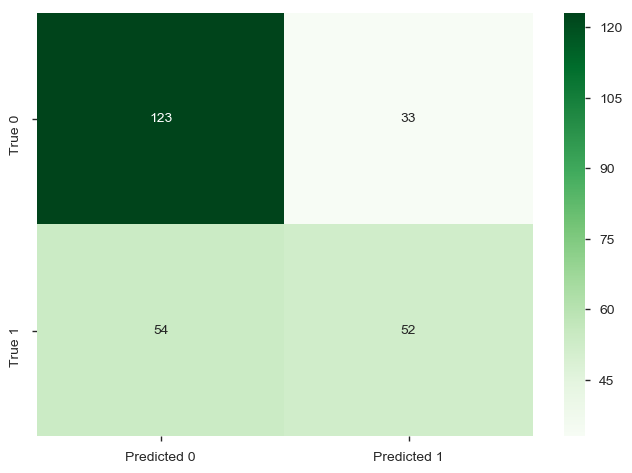

```python
#Confusion Matrix
print("Confusion Matrix")
cf = metrics.confusion_matrix(y_test,predictions)
lbl1 = ["Predicted 0","Predicted 1"]
lbl2 = ["True 0", "True 1"]
sns.heatmap(cf, annot=True, cmap="Greens", fmt="d", xticklabels=lbl1, yticklabels=lbl2)
plt.show()
```

## Hyper-parameters Optimization using Gridsearch and Crossvalidation

```python
svc = SVC()
svc.get_params()
param_grid = [{'C':[0.01,1,10,100,1000],
              'kernel':['linear','poly','rbf','sigmoid'],
              'gamma':[0.01,1,10,100,200]}]
```

```
{'C': 1.0,
 'cache_size': 200,
 'class_weight': None,
 'coef0': 0.0,
 'decision_function_shape': 'ovr',
 'degree': 3,
 'gamma': 'auto_deprecated',
 'kernel': 'rbf',
 'max_iter': -1,
 'probability': False,
 'random_state': None,
 'shrinking': True,
 'tol': 0.001,
 'verbose': False}
```

```python
'''model = GridSearchCV(svc, param_grid, cv=10, scoring='accuracy')
model.fit(X_train, y_train)
model.best_params_
model.best_score_'''
#Committed the code it is taking to much time in compiling
```

```
"model = GridSearchCV(svc, param_grid, cv=10, scoring='accuracy')\nmodel.fit(X_train, y_train)\nmodel.best_params_\nmodel.best_score_"
```

## Random Forest

```python
radm_clf = RandomForestClassifier(max_depth = 3,n_estimators=100)
radm_clf.fit( X_train, y_train )
```

```
RandomForestClassifier(bootstrap=True, class_weight=None, criterion='gini',
            max_depth=3, max_features='auto', max_leaf_nodes=None,
            min_impurity_decrease=0.0, min_impurity_split=None,
            min_samples_leaf=1, min_samples_split=2,
            min_weight_fraction_leaf=0.0, n_estimators=100, n_jobs=None,
            oob_score=False, random_state=None, verbose=0,
            warm_start=False)
```

```python
radm_test_pred = pd.DataFrame( { 'actual':  y_test,
                            'predicted': radm_clf.predict( X_test ) } )
```

```python
metrics.accuracy_score( radm_test_pred.actual, radm_test_pred.predicted )
```

```
0.8129770992366412
```

```python
radm_train_pred = pd.DataFrame( { 'actual':  y_train,
                            'predicted': radm_clf.predict( X_train ) } )
```

```python
metrics.accuracy_score( radm_train_pred.actual, radm_train_pred.predicted )
```

```
0.8194842406876791
```

```python
param_grid = {'max_depth': np.arange(3, 11),
             'max_features': np.arange(3,11)}
```

```python
ran_forest = GridSearchCV(RandomForestClassifier(), param_grid, cv = 10)
ran_forest.fit(X_train, y_train )
```

```
GridSearchCV(cv=10, error_score='raise-deprecating',
       estimator=RandomForestClassifier(bootstrap=True, class_weight=None, criterion='gini',
            max_depth=None, max_features='auto', max_leaf_nodes=None,
            min_impurity_decrease=0.0, min_impurity_split=None,
            min_samples_leaf=1, min_samples_split=2,
            min_weight_fraction_leaf=0.0, n_estimators='warn', n_jobs=None,
            oob_score=False, random_state=None, verbose=0,
            warm_start=False),
       fit_params=None, iid='warn', n_jobs=None,
       param_grid={'max_depth': array([ 3,  4,  5,  6,  7,  8,  9, 10]), 'max_features': array([ 3,  4,  5,  6,  7,  8,  9, 10])},
       pre_dispatch='2*n_jobs', refit=True, return_train_score='warn',
       scoring=None, verbose=0)
```

```python
ran_forest.best_score_
```

```
0.8213944603629417
```

```python
ran_forest.best_estimator_
```

```
RandomForestClassifier(bootstrap=True, class_weight=None, criterion='gini',
            max_depth=7, max_features=5, max_leaf_nodes=None,
            min_impurity_decrease=0.0, min_impurity_split=None,
            min_samples_leaf=1, min_samples_split=2,
            min_weight_fraction_leaf=0.0, n_estimators=10, n_jobs=None,
            oob_score=False, random_state=None, verbose=0,
            warm_start=False)
```

```python
ran_forest.best_params_
```

```
{'max_depth': 7, 'max_features': 5}
```

```python
ran_forest = RandomForestClassifier( max_depth = 8, max_features=7 )
ran_forest.fit( X_train, y_train )
```

```
RandomForestClassifier(bootstrap=True, class_weight=None, criterion='gini',
            max_depth=8, max_features=7, max_leaf_nodes=None,
            min_impurity_decrease=0.0, min_impurity_split=None,
            min_samples_leaf=1, min_samples_split=2,
            min_weight_fraction_leaf=0.0, n_estimators=10, n_jobs=None,
            oob_score=False, random_state=None, verbose=0,
            warm_start=False)
```

```python
radm_test_pred = pd.DataFrame( { 'actual':  y_test,
                            'predicted': radm_clf.predict( X_test ) } )
```

```python
metrics.accuracy_score( radm_test_pred.actual, radm_test_pred.predicted )
```

```
0.8129770992366412
```

## Evaluating a score by cross-validation using sklearn cross_val_score

```python
def compute_score(clf, X, y, scoring='accuracy'):
    xval = cross_val_score(clf, X, y, cv = 5, scoring=scoring)
    return np.mean(xval)

def compute_precision(clf, X, y, scoring='precision'):
    xval = cross_val_score(clf, X, y, cv = 5, scoring=scoring)
    return np.mean(xval)

def compute_recall(clf, X, y, scoring='recall'):
    xval = cross_val_score(clf, X, y, cv = 5, scoring=scoring)
    return np.mean(xval)

#Accuracy scores from various models
logreg = LogisticRegression()
logreg_cv = LogisticRegressionCV()
rf = RandomForestClassifier(random_state=0, n_estimators=100,max_depth = 8, max_features=7)
gboost = GradientBoostingClassifier()
dtree = DecisionTreeClassifier(criterion="gini",max_depth=5)
svm = SVC()
naiveBayes = GaussianNB()

models = [logreg, logreg_cv, rf, gboost, dtree, svm, naiveBayes]
```

```python
for model in models:
    print ('Cross-validation of : {0}'.format(model.__class__))
    score = compute_score(clf=model, X=X_train, y=y_train, scoring='accuracy')
    precision = compute_precision(clf=model, X=X_train, y=y_train, scoring='precision')
    recall = compute_recall(clf=model, X=X_train, y=y_train, scoring='recall')
    print ('Accuracy score  = {0}'.format(score))
    print ('Precision score = {0}'.format(precision))
    print ('Recall score    = {0}'.format(recall))
    print ('****')
```

```
Cross-validation of : <class 'sklearn.linear_model.logistic.LogisticRegression'>
Accuracy score  = 0.806035762483131
Precision score = 0.7448848288168581
Recall score    = 0.7383317104836091
****
Cross-validation of : <class 'sklearn.linear_model.logistic.LogisticRegressionCV'>
Accuracy score  = 0.8098680705259653
Precision score = 0.7656543532744906
Recall score    = 0.7206101914962675
****
Cross-validation of : <class 'sklearn.ensemble.forest.RandomForestClassifier'>
Accuracy score  = 0.8184394114657273
Precision score = 0.8076267367313849
Recall score    = 0.6825056799740344
****
Cross-validation of : <class 'sklearn.ensemble.gradient_boosting.GradientBoostingClassifier'>
Accuracy score  = 0.820403631456263
Precision score = 0.8113167126625289
Recall score    = 0.6851022395326193
****
Cross-validation of : <class 'sklearn.tree.tree.DecisionTreeClassifier'>
Accuracy score  = 0.801278370752055
Precision score = 0.7994816698996045
Recall score    = 0.6597208698474522
****
Cross-validation of : <class 'sklearn.svm.classes.SVC'>
Accuracy score  = 0.7239526701368807
Precision score = 0.6732900669061996
Recall score    = 0.5151574164232391
****
Cross-validation of : <class 'sklearn.naive_bayes.GaussianNB'>
Accuracy score  = 0.46886692255113305
Precision score = 0.4120456194949987
Recall score    = 0.921291788380396
****
```

```python
Image(url= "titanic_survived.jpg")
```

[figure not shown]

```python
Image(url= "titanic_survived1.jpg")
```

[figure not shown]

Millvina Dean — a name she used throughout her life, though she was christened Elizabeth Gladys Dean — spent her early years on a farm owned by her grandfather, a Southampton veterinarian.

She survived with her mother, Georgetta, and 2-year-old brother when they, like many other survivors, were picked up by the liner Carpathia and taken to New York.

Ms. Dean said all she knew of what happened during the sinking she had learned from her mother: “She told me that they heard a tremendous crash, and that my father went up on deck, then came back down again and said, ‘Get the children up and take them to the deck as soon as possible, because the ship has struck an iceberg.’ ”

Her father, Bertram Dean, was among more than 1,500 passengers and crew members who died in the sinking, a fact that Ms. Dean, in an interview at the Southampton nursing home last month, attributed partly to the fact that the Dean family was traveling in third class, or steerage, as the cheapest form of passage was known. https://www.nytimes.com/2009/06/01/world/europe/01dean.html

### Below are the records as mentioned by Millvina Dean from our exisitng Dataset.

```python
titanicData[titanicData.name.isin(['Dean, Master. Bertram Vere','Dean, Miss. Elizabeth Gladys "Millvina"','Dean, Mr. Bertram Frank','Dean, Mrs. Bertram (Eva Georgetta Light)'
])]
```

|  | pclass | survived | name | sex | age | sibsp | parch | ticket | fare | cabin | embarked | boat | body | home.dest | title |
| --- | --- | --- | --- | --- | --- | --- | --- | --- | --- | --- | --- | --- | --- | --- | --- |
| 762 | Third | 1 | Dean, Master. Bertram Vere | male | 1.0000 | 1 | 2 | C.A. 2315 | 20.575 | NaN | Southampton | 10 | NaN | Devon, England Wichita, KS | Master |
| 763 | Third | 1 | Dean, Miss. Elizabeth Gladys "Millvina" | female | 0.1667 | 1 | 2 | C.A. 2315 | 20.575 | NaN | Southampton | 10 | NaN | Devon, England Wichita, KS | Miss |
| 764 | Third | 0 | Dean, Mr. Bertram Frank | male | 26.0000 | 1 | 2 | C.A. 2315 | 20.575 | NaN | Southampton | NaN | NaN | Devon, England Wichita, KS | Mr |
| 765 | Third | 1 | Dean, Mrs. Bertram (Eva Georgetta Light) | female | 33.0000 | 1 | 2 | C.A. 2315 | 20.575 | NaN | Southampton | 10 | NaN | Devon, England Wichita, KS | Mrs |